# YCHI5045M Introduction to Statistics for Health Scientists: Computer Sessions Notes & Exercises

# 11 The chi-square test of independence

## 11.1 Overview

While the independent and paired t-tests allow us to analyse the association between a numerical outcome and a binary independent variable, the chi-squared (or chi-square) test of independence allows us to analyse whether there is an association between a categorical outcome (with any number of category levels) and a categorical independent variable (again with any number of category levels), in terms of whether the relative frequency of observations across category levels in the outcome differs depending on the category level of the independent variable. It’s probably called the chi-squared test of *independence* because it uses the chi-square distribution and the inferential part of the test is a hypothesis test where the null hypothesis is that no association exists between the outcome and independent variable, i.e. that they are independent.

For example, assume we are interested in whether there is an association between hypertension (a binary outcome) and socio-economic status, defined as having three levels: low, medium and high. Here for our purposes of illustration we don’t define these levels further, but in a real study they would be based on some, usually multivariate, computation/analysis. Statistically, we would be interested in whether the relative frequency (i.e. proportion/percentage) of hypertension differed depending on whether individuals were classed as being of low, medium, or high socio-economic status. This type of analysis could then be done using a chi-square test of independence (also called Pearson’s chi-square test after the inventor of the method, or the chi-square test of association), but note that the two categorical variables can have any number of levels.

The chi-square test of independence is still quite popular for such situations, which is why we are covering it, but it does have some big limitations and we’ll see later how to use a much more useful approach is logistic regression. Note: although the p-value calculated for the test is based on the chi-squared distribution the test itself does not assume the underlying data follow any specific distribution and so it is technically a non-parametric test.

## 11.2 Scenario

Using the “SBP data final.sav” dataset we’ll analyse whether there is an association between individuals’ hypertension status (hypertension/no hypertension), based on having a systolic blood pressure <140 mmHg or ≥140 mmHg, and their sex (asumed to just be male/female), and then you can try a similar analysis by yourself.

## 11.3 Step 1: check the assumptions of the chi-squared test of independence

Video: check the assumptions of the chi-squared test of independence

**1. Both the outcome and the independent variable should be categorical (either ordinal or nominal), each having at least two levels**

This is clearly the case.

**2. Observations should be independent**

As with the independent t-test observations should not be related/correlated, such as would be the case if observations are collected from entities within clusters, such individuals clustered within families, health facilities or other institutions etc. Again, the only way to verify this is from a full understanding of the study design and data collection processes. Here we can assume this holds because the data come from a simple random survey of separate individuals.

**3. Ideally no cell has an expected frequency less than 5 and no cells have expected values of 0**

We can only check this assumption from the results once we’ve run the test. As we’ll see below cells are just the cross-classified category levels between the outcome and independent variable. For example, if the outcome is hypertension (hypertension/no hypertension) and the independent variable is sex (female/male) then you would have four cells: yes-female, yes-male, no-female, and no-male. We’ll also see below what the “expected” values are.

Note: this is not really a formal rule and other researchers provide other thresholds such as no expected frequency less than 10. However, when any expected cell frequency is less than 5, particularly when there are few category levels in both outcome and independent variable (e.g. with a “2 x 2 contingency table” where both variables just have two levels), some researchers recommendation applying “Yates’s correction” (named after its creator) that aims at correcting the error introduced by assuming that the discrete probabilities of frequencies in the table can be approximated by a continuous distribution (chi-squared). However, this has been shown to result in overly conservative hypothesis tests and so other researchers prefer to use Fisher’s Exact test, which is what we will mention here later. Remember you can always do a sensitivity analysis: run both versions and present both and interpret in terms of any differences.

However, if any cells have expected values of 0 you must merge the relevant category level in the independent variable with one or more (logically chosen) category levels to ensure no expected values are 0. For example, if our outcome was hypertension status (hypertension/no hypertension) and our independent variable was socio-economic status (low/medium/high) and we found that our “hypertension status = no, socio-economic status = low” cell had an expected frequency of 0 you could merge the low socio-economic status level with the medium socio-economic status level and see if that solved the problem.

## 11.4 Step 2: run the chi-squared test of independence

Video: run the chi-squared test of independence

- Let’s run the test. First, load the “SBP data final.sav” dataset. From the main menu go: Analyze > Descriptive Statistics > Crosstabs. Then in the Crosstabs tool add the htn variable to the Row(s): box and the sex variable to the Column(s): box. Note: you can put either variable in either box (so don’t worry about it when doing your own analysis) as it doesn’t make any difference to the calculations, they will just be presented in the resulting cross tabulation table the other way around (this way round seems most logical to me, but you may disagree). Then click the Statistics button and tick the Chi-square box at the top-left, and then also tick the Phi and Cramer’s V box under Nominal (we’ll explain what these are later), then click Continue.
- Let’s also edit the options for the descriptive tables that SPSS will produce, so we can see the observed and expected counts and frequencies (as percentages). Click the Cells button and under Counts ensure Observed and Expected are ticked, and under Percentages ensure Row, Column and Total are ticked.
- Let’s also produce some clustered bar charts to help us interpret the results visually, which SPSS helpful allows us to do via the tool by ticking the Display clustered bar charts box.
- Finally click OK.

## 11.5 Step 3: understand the results tables and extract the key results

Video: understand the results tables and extract the key results

- In the output window you’ll see four tables and a bar chart. The first table titled “Case Processing Summary” just tells us how many “cases” were included or excluded in the analysis. A case represents an observation, which in our dataset represents a separate participant who had data on both categorical variables. So for example if a participant lacked data for either their hypertension status or their sex (or both) they would be excluded from the analysis. We can see none (0%) of the observations (participants) had to be excluded due to missing values.
- We will skip the second table for now and next look at the third table down titled “Chi-Square tests”. This primarily gives us the inferential result for our chi-square test of independence, which is just in the form of a p-value from a hypothesis test that you interpret along side the point estimates of the outcome frequencies in each group of the independent variable. Note: in addition to the chi-square test of independence we also get (without asking) results from some other related tests that we won’t consider further, and in the final row of the table we get the total number of valid (i.e. non-missing) cases again. Just look at the top row (Pearson Chi-Square) for the results from our chi-square test of independence.

What does it all mean?

**Chi-Square tests section columns explained**

**Value**

- This gives us the test statistic which is the chi-square (χ2) test statistic. It is used to compute the p-value, but you can ignore the value of the test statistic itself.

**df**

- This is the degrees of freedom (df) for the test/p-value. It represents a measure of how many pieces of statistical information (observations) were freely available for the test. You can ignore this.

**Asymp. Sig. (2-sided)**

- This is our chi-square test of independence two-sided p-value. “Asymp. Sig. (2-sided)” stands for asymptotic significance (2-sided). This two-sided (or two-tailed) part means the p-value is computed on the assumption that the association between the outcome and independent variable could be in either direction, while the “asymp.” part means that the rest assume an infinite sample size. The infinite sample size assumption is obviously not true but may be a reasonable and useful approximation. What represents a “reasonable sample size” isn’t easy to work out, but rough rules of thumb (a “rule of thumb” is an English language saying for a rough guide) usually say at least >30 observations and no cell with <5 observations.
- As you can see our chi-squared test of independence p-value is **0.000** (i.e. <0.001 as if you remember SPSS does not give exact p-values once P<0.001). This is lower than the standard 0.05 threshold for claiming “statistical significance”.

We can actually ignore the remaining two columns: “Exact Sig. (2-sided)” and “Exact Sig. (1-sided)”. This is because as they don’t apply to our test, only if you were interested in the results of “Fishers Exact test”.

Note: see the footnotes to the table. One reads “0 cells (0.0%) have expected counts less than 5…”, which means that this assumption of the test was not violated and so we can interpret our results.

Now let’s come back to the second table titled “Hypertension (SBP >= 140 mmHg) * Sex (male/female) Crosstabulation” where this information comes from and understand it.

**Hypertension (SBP >= 140 mmHg) * Sex (male/female) Crosstabulation table explained**

This is a cross tabulation showing us a range of statistics for each cell, where each cell is defined by one of the unique combinations of the two categorical variables’ levels (i.e. with two binary categorical variables we have 2x2 = 4 cells: htn = yes and sex = male, htn = yes and sex = female, htn = no and sex = male, and htn = no and sex = female). In addition the total value of each statistic is presented within each level of each categorical variable across the levels of the other categorical variable (e.g. the total for htn = no across both sex = male and sex = female). Within each cell we have the following statistics/values:

**Count**

- The number of observations (participants) in each cell.

**Expected Count**

- The expected number of observations calculated using the formula: (row total x column total) / overall total. This calculated the expected number of observations per cell if there was no association between the two variables.

**% within Hypertension (SBP >= 140 mmHg)**

- This is the % of observations (relative frequencies) within each level of hypertension for the relevant level of sex.

**% within Sex (male/female)**

- This is the % of observations (relative frequencies) within each level of sex for the relevant level of hypertension.

**% of Total**

- This is the % of observations (relative frequencies) within each cell out of the total number of observations.

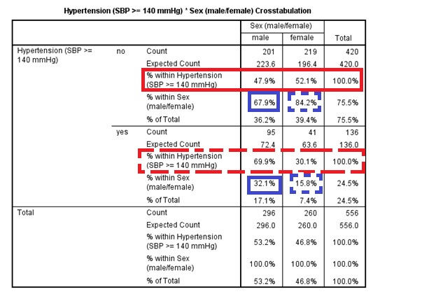

Because of the way the table is laid out (with sex along the top and htn down the side) it makes most sense to look at the results from the “point of view” of the htn variable, looking at the relative frequency of men and women for each level of htn. So to do this with the above table we are looking across the rows at the “% within Hypertension…” values. First look at the row outlined in solid red for htn = no. This tells us that out of the individuals who were htn = no 47.9% were men and 52.1% were women. Next look at the row outlined in dashed red for htn = yes. This tells us that out of the individuals who were htn = yes 69.9% were men and 30.1% were women. Therefore, there appears to be a strong association between hypertension status and sex, with men being more likely to be hypertensive than women, i.e. as we “move” from one level of htn to the other the relative frequency of sex varies substantially from roughly 50%:50% to roughly 70%:30%. We can also look at these results from the “point of view” of the sex variable, but now because of the way the table is laid out it makes more sense to look down the sex level columns or reproduce the table with the variables the other way around. Look at the values outlined in solid blue in the male column. These show us that of the individuals who were men 67.9% were not hypertensive and 32.1% were. Finally look at the values outlined in dashed blue in the female column. These show us that of the individuals who were female 84.2% were not hypertensive and 15.8% were. So again it indicates the same direction and strength of association, because it’s the same data, but looking from “the point of view” of the other variable. I find looking from the “point of view” of the assumed outcome variable more logical and intuitive (i.e. the first “view”) because it’s the assume causal relationship, but you may disagree.

Lastly we come to the fourth table “Symmetric Measures”. This presents the Phi and Cramer’s V statistics and their associated p-values. The statistics both measure the strength of the association between the two variables in the analysis, and both go from 0 (no association) to 1 (“perfectly” associated). The associated p-value shows you, assuming the Phi/Cramer’s V value is 0, how likely you were to observe a value at least as great as the one observed due to sampling error alone. These statistics can help you interpret how strong any association is, but they are difficult to interpret. When both variables have two levels then they are equivalent in interpretation to a linear correlation coefficient with a simple and useful interpretation (the strength of association on a 0-1 or 0-100% scale), but when there are more than two levels in one or both variables there’s no clear intuitive interpretation!

Therefore, I would recommend firstly looking at the p-value to see if there is any reasonable evidence for an overall association between your two categorical variables (i.e. based on the standard P ≤ 0.05 threshold), and the looking at the relative frequencies (% of observations within different levels of one variable for each level of the other) as we have done above to judge where any associations might exist, in what direction and how strong they appear to be.

## 11.6 Step 4: report and interpret the results

This allows readers to understand the direction and possible size of associations between the relative outcome frequencies in each of the independent variable groups, and the associated inferential hypothesis test p-value result, which loosely speaking gives us a sense of how confident we can be in concluding that the exact observed association in the sample represents the association that exists in the target population.

## 11.7 Limitations

Limitations

The main limitation of the chi-square test of independence is that we do not get any confidence intervals on our raw measures of effect size: the relative frequencies (i.e. the raw measure of the direction and strength of the association). We only get an overall p-value that tells us, assuming there is no association between the two categorical variables, how likely we are to have observed an association (in either direction) at least as great as the one we have observed due to sampling error alone. So all it can indicate is if there is likely to be an overall association between the two variables given the uncertainty in the data. It tells us nothing about the direction or size of any association, or which levels it involves.

When both variables have two levels, like with our example, we know any association must be between both levels of each variable. However, when there are more than two levels in one or both variables it’s even less clear. For example, assume we looked at the association between the htn and ses variables. If we found the p-value for a chi-square test of independence was < 0.05 we could conclude there was evidence for an overall association. However, we could get a significant p-value if the relative frequency of hypertension was similar for two levels of ses and only differed for the remaining level, or we could get a significant p-value if the relative frequency of hypertension was different among all three levels of ses. Therefore, all we can do is conclude whether there is evidence for an overall association based on the p-value, and then cautiously interpret the relative frequencies (measures of effect) to see which levels, what direction and what size of associations appear to exist. As you can see this is much, much less robust and satisfactory than having confidence intervals for our raw measures of effect size.

## 11.8 Expected cell counts <5

What if one or more of our expected cell counts are <5? Then we can use a similar test that can deal with this problem (but is typically less powerful when it’s not an issue) called the Fisher’s Exact test. To include this test in our chi-square results table when we go to the Crosstabs tool add in the variables as above but now click the Exact button and then tick the Exact button (you can leave the Time limit per test as it is). Then click OK and in the Chi-Square Tests table you will see an additional row called Fisher’s Exact Test. Again all we get is a two-sided p-value (“Exact Sig. (2-sided)”) based on the test statistic (“Value”) given the degrees of freedom (“df”), which as always just tells us, assuming the null hypothesis is true, how likely we were to have observed data reflecting a relationship that differed from the null hypothesis at least as greatly as that observed.

## 11.9 Exercise: chi-square test of independence

Using the “SBP final data.sav” dataset and via the process outlined above use a chi-square test of independence to analyse the relationship between BMI and ACE inhibitor usage during the past three months, with the hypothetical research question being is BMI related to ACE inhibitor usage?

- First convert the BMI variable into a binary variable based on BMI values <30 kg/m² and those ≥ 30 kg/m².
- Run the chi-square test of independence using the new categorical variable BMI (<30 kg/m² or ≥ 30 kg/m²) and ace.
- Hint: enter your new categorical BMI variable into the Row(s): box in the Crosstabs tool and then in the Crosstabulation table look across the top and bottom halves of the table. For example, the top half of the table will, depending on how you’ve coded your BMI categorical variable, include the count (frequency) and % of individuals who reported (yes) and did not report (no) using ACE inhibitors during the past month within the relevant BMI group. You can then compare the frequency and % of individuals reporting usage between the two BMI groups, along with the chi-square p-value result in the following table.
- In the YCHI5045M computer sessions materials “Exercises” folder open the “Exercises.docx” Word document and scroll down to **Chi-square test of independence: the relationship between BMI and ACE inhibitor usage**.
- Write a couple of sentences reporting the results of your analysis. Include the basic descriptive statistics: overall sample size and frequency and proportion/percentage of individuals with low and high BMI who reported using ACE inhibitors during the past three months. Also be sure to include sufficient details about the type of analysis used, and of course the key inferential result. Round results to one decimal place. You don’t need to explain anything about the study or interpret the clinical or practical importance of the result.
- Write a sentence or two about the key limitations of this analysis *in terms of interpreting the result*.
- Once you’ve completed this compare your reporting to the below example text.

I analysed the relationship between BMI, defined/grouped as <30 kg/m² or ≥30 kg/m², and ACE inhibitor usage during the past three months. Out of a total sample size of 529 individuals, among individuals with reported BMI values <30 kg/m² 4.7% (20/429) reported using ACE inhibitors during the past three months while among individuals with reported BMI values ≥ 30 kg/m² 7% (7/100) reported using ACE inhibitors during the past three months, but this difference was not statistically significant (P = 0.3) based on a chi-square test of independence. Therefore, there was no clear evidence for a relationship between BMI when grouped as <30 kg/m² or ≥30 kg/m² and ACE inhibitor usage frequency during the past three months in this target population. However, the key limitation of this analysis is that it does not adjust for any other confounding variables, of which there are likely to be many (especially in an observational cross-sectional study like this). Therefore, this is likely to represent a biased estimate of the independent relationship between BMI (as defined/grouped here) and ACE inhibitor usage within the past three months in this target population.

# 12 The chi-square goodness-of-fit test

There is another chi-squared based test usually called the chi-squared goodness-of-fit test. We will not practice this test here as it’s far less commonly required/used than the chi-squared independence test, but we will briefly explain its use here. In brief, the chi-squared goodness-of-fit test is a nonparametric test for single variables that is used to analyse whether the distribution of cases (units of observation) in a single categorical variable follows a known or hypothesised distribution. For example, whether the proportion of males and females in a sample follows the distribution of males and females in a given target population, or a distribution that is “hypothesised”, such as the proportion of males compared to females that we expect to have a certain characteristic/disease etc.

A good overview of the test with instructions of how to use it in SPSS can be found here: https://statistics.laerd.com/spss-tutorials/chi-square-goodness-of-fit-test-in-spss-statistics.php

# 13 Analysing paired/correlated categorical outcomes

If your outcome consists of a binary variable and your independent variable has just two groups but observations in each group are paired/correlated then you could analyse such data using McNemar’s test. Similarly, if your outcome consists of a binary variable but your independent variable has three or more groups but observations in each group are related/correlated then you could analyse such data using Cochran’s Q test. We will not practice these analyses as they are not commonly done, but good overviews including instructions for how to do them in SPSS can be found here:

https://statistics.laerd.com/spss-tutorials/mcnemars-test-using-spss-statistics.php https://statistics.laerd.com/spss-tutorials/cochrans-q-test-in-spss-statistics.php

However, a far more flexible and in many ways far more informative analytical method would be to use a multi-level logistic regression model (or even a multinomial multi-level model if your outcome has three or more levels). These approaches allow you to both adjust for other covariates, explicitly model multi-level correlations, and estimate measures of effect sizes with confidence intervals, not just p-values! They are beyond the scope of an introductory statistics course, but the University of Bristol offers an excellent, free, online module-based learning course on multi-level modelling, which includes instructions for how to do such analyses in SPSS as well as most other commonly used statistical software packages like R and Stata:

http://www.bristol.ac.uk/cmm/learning/online-course/course-topics.html

# 14 Multiple linear regression

## 14.1 Key terminology and concepts

If necessary please read the below guide to key terminology and concepts before reading further as we will be using these terms when discussing linear regression and the modelling process in SPSS without further explanation.

- **Model** = Loosely speaking the outcome variable and the set of independent variables that you are analysing via linear regression, plus their functional form (see below). Note: although simpler analyses like the independent t-test are referred to as “statistical tests”, creating the false illusion of a fundamental difference from regression “modelling”, they have the same underlying mathematical form. Simply put, parameteric statistical tests like the independent t-test are models too.
- **Functional form/model parameterisation** = In what mathematical form you add independent variables to your model. Practically speaking this is whether your model assumes 1) a simple linear relationship between a given independent variable and the outcome (also called a “main effect”), or 2) an interaction between a given independent variable and one or more other independent variables and the outcome, or 3) a non-linear relationship between a given independent variable and the outcome (although many other functional forms are possible).
- **Model building** = The process by which you decide which independent variables to include in your model.
- **Coefficient or parameter or (model) term** = The point estimate measuring/indicating the direction and size of the relationship between a given independent variable and the outcome that your linear regression estimates.
- **Focal relationship** = A relationship between a given independent variable and an outcome that is the focus of the analysis and research question, such as the effect of smoking status on systolic blood pressure.
- **Confounder or confounding variable** = With respect to a focal relationship, say the effect of smoking status on systolic blood pressure, a confounder or confounding variable is a “common cause” of both the independent variable of interest (smoking status) and the outcome (systolic blood pressure). For this example a plausible confounder might be “stress level”, because it’s very plausible that stress can induce people to take up smoking or restart smoking and that stress can increase blood pressure on its own.
- **Competing exposure** = With respect to a focal relationship, say the effect of smoking status on systolic blood pressure, a competing exposure is a cause of the outcome but is not caused by the independent variable of interest and does not cause the independent variable of interest. For this example a plausible competing exposure might be the presence of a certain gene that predisposes individuals to high blood pressure, whilst having no effect on their likelihood of taking up smoking or remaining a smoker, because it would, on average, lead to higher blood pressure in individuals but not affect their likelihood of smoking.
- **Sufficient adjustment set** = With respect to a focal relationship, say the effect of smoking status on systolic blood pressure, a sufficient adjustment set is a set of variables that, if fully “conditioned on” (i.e. adjusted for by including in a regression model), will provide an unbiased estimate for the causal effect of the independent variable of interest by adjusting for all sources of confounding.

## 14.2 Overview with a focus on causal inference from observational data

Multiple linear regression is used to analyse the relationship(s) between one numerical outcome variable and one or more independent variables that can be numerical or categorical or a mixture of both. When you have one numerical outcome and one numerical or categorical independent variable this is sometimes referred to as “simple linear regression”, but there’s no qualitative difference from multiple linear regression, and we’ll often just refer to “linear regression” from here on. Note: when we have one outcome variable and multiple independent variables it is a multiple linear regression not a multivariate linear regression. Multivariate refers to analyses of more than one outcome variable.

Linear regression modelling is therefore an extremely flexible and powerful method of analysis. Linear regression models are used for a variety of purposes, but primarily they are used for prediction and causal inference. Prediction models (actually more often using logistic regression) are typically used for diagnosis or prognosis, and are usually developed using more or less “theory free” and automated methods, where data are primarily used to build the model. However, most research in the health sciences focuses on attempting to understand causes of outcomes, such as does smoking cause lung cancer? This has historically been what “statistical inference” tended to mean, at least in practice. In the context of robust randomised controlled trials it is generally accepted that causal effects can be clearly identified, and you can certainly use regression models to this as appropriate to the data. However, in the context of observational studies it is generally accepted to be much more challenging to clearly identify causal effects, primarily due to the challenges of accurately modelling the processes generating your outcome of interest and avoiding various source of bias such as confounding and other less well known biases.

Broadly speaking, in the context of observational studies the historical, and still dominant, approach to trying to understand causal effects has been the following: 1) collect some data on an outcome of interest and a range of independent variables thought to be possible causes or confounders, 2) use a mix of theory and data-driven choices to build a regression model that is the “best” in some sense, usually at minimising the unexplained variation in the outcome, and 3) interpret all the independent variables as causal effects in relation to the outcome, at least implicitly. I say implicitly because the typical approach in research using observational studies, given the limitations of observational designs at robustly and clearly identifying causal effects, has been to refer to the relationships identified between independent variables and outcomes as “associations” or another similar term. In such studies researchers usually also state that causation cannot be inferred from the study given its limitations, but then in practice still treat the identified relationships as causal, which is clearly not a very satisfactory approach!

For a while now though a field know as “causal inference” has been developing and promoting methods for less biased analysis of causal research questions in observational studies, as it has become increasingly clear that existing methods and approaches have some substantial (and often hidden and/or counterintuitive) biases. Most of the learning and approaches from this field are beyond the scope of this introductory course, but we will try and incorporate some of the key ideas and findings below, while acknowledging the gaps.

Very simply speaking, particularly in the context of observational studies, research has shown that data-driven automated model selection processes typically lead to biased models that cannot identify and accurately estimate causal relationships, while also producing inferential results that have falsely inflated precision and power. Research has also shown that it is typically not valid to interpret the results of a regression model in terms of *all the independent variables* in the model reflecting causal relationships. This is known as the “Table 2 fallacy”.

Instead, within a given study every focal relationship of interest, say the relationship between stress and blood pressure, should be analysed using a separate model containing its own set of independent variables (other than the independent variable of focal interest), which may or may not differ from the set of independent variables used when analysing a different focal relationship of interest within the data, say the relationship between BMI and blood pressure. Broadly speaking, each model for every separate focal relationship of interest should contain a “sufficient adjustment set” of independent variables that suitably adjust for *all key sources of confounding of that relationship*, and this set of variables should be chosen based on theory and plausible/sensible decisions, not via a data-driven automated process.

In this practical and course we will not go further into these aspects of causal inference, and please be clear that this is just a very simplistic overview of a few of the key principles of causal inference as it relates to analysing observational data using regression models, but there is much more to learn and many details are not covered! However, we will take some of these key principles forward. Specifically, for this linear regression and the following logistic regression practical sessions we will assume we are aiming to make causal inferences about the likely causes of variation in systolic blood pressure and hypertension status respectively using the SBP data, which we assume to have come from an observational study (specifically a cross-sectional design). We will be interested in the assumed causal effects of all the available independent variables. We will not use any form of data-driven automated process when building our model, but we will select a single set of independent variables that we assume represents the sufficient adjustment set of variables for each variable in that set. That is, we will interpret the relationship of each independent variable in our single model as though it was an estimate of a possible causal effect between itself and the outcome based on a single model, i.e. we will assume that every independent variable in our model is a focal relationship of interest. However, please bear in mind that while this practice is extremely common in the scientific literature, as discussed above in practice this would almost certainly be committing the “Table 2 fallacy”, and it’s just for the purposes of keeping things simple that we won’t try and create sufficient adjustment sets for every focal relationship.

### 14.2.1 Causal inference references

If you are likely to carry out quantitative research in your dissertation and/or later career I would strongly advise that as well as putting time and effort into learning statistics, i.e. analysing data, that you put time and effort into learning about causal inference and put into practice as many of the recommended approaches as you can. Although it’s still somewhat of an emerging field learning from it is being adopted rapidly by epidemiology and the health sciences, and understanding at least the basic principles and key recommendations will really benefit your research and expertise.

Some very useful causal inference references are:

Hernan and Robins’ causal inference book. This is an excellent and comprehensive book. It gets quite technical in places but there’s not necessarily a way to simplify things further. If you want to do robust causal inference it’s not a simple or easy thing unfortunately.

- https://www.hsph.harvard.edu/miguel-hernan/causal-inference-book/

Free online course about using directed acyclic diagrams (DAGs) to select variables for models. DAGs are a brilliant and relatively easy to use tool for thinking through what independent variables constitute a sufficient adjustment set for a given focal relationship when planning an analysis of data relating to that focal relationship. They are highly recommended by causal inference practitioners, and are literally just diagrams - no maths involved.

https://www.edx.org/course/causal-diagrams-draw-your-assumptions-before-your

Table 2 fallacy paper.

- https://academic.oup.com/aje/article/177/4/292/147738

Why step-wise selection methods commonly used to build regression models are bad.

- https://towardsdatascience.com/stopping-stepwise-why-stepwise-selection-is-bad-and-what-you-should-use-instead-90818b3f52df

### 14.2.2 Interactions and non-linear relationships

Linear regression can also be used to look at interactions between different variables (e.g. how the relationship between smoking status and systolic blood pressure changes based on sex), and to model non-linear relationships (e.g. the relationship between age and blood pressure, which is typically fairly flat at young ages and then increases through middle age before flattening out). In practice most processes/phenomena interact and are non-linear to a greater or less extent, but it is often a reasonable simplifying assumption to treat variables as independent (non-interacting) and relationships as linear, unless the interactions and/or non-linear relationships are clearly strong or a key part of your research question. Therefore, as these issues are complicated and often not required when analysing maybe most data simple datasets we will not look at them further or practice the techniques needed to model interactions and non-linear relationships.

Note: the “linear” part of linear regression refers to the fact that in the linear regression model the coefficients or parameters are “linear”, i.e. the model is just a simple sum of those coefficients:

> y = α + β1X1 + β2X2 + … + βnXn

Where y is the model predicted outcome value, α is the intercept, the βs are the independent variable coefficients and the Xs are the independent variable values.

## 14.3 Scenario

We wish to understand all the main likely causes of variation in individuals’ systolic blood pressure using the data collected in the SBP dataset. We’ll use a linear regression model/analysis to look at this question. Refer to the “The datasets” section within the “Introduction to SPSS” section for full details if you need a full reminder, but briefly this dataset contains data on 556 individuals who were (hypothetically speaking!) sampled in a cross-sectional survey, and had data collected on their systolic blood pressure plus certain socio-demographic (age, sex, socio-economic status) and health characteristics (BMI, salt intake and ACE inhibitor usage).

As discussed above we will assume, based on existing theory/evidence and plausible, critical thinking, that all our measured independent variables are all likely causes of variation in systolic blood pressure and collectively simultaneously act as a sufficient adjustment set when interpreting each independent variable’s relationship with the outcome causally. That is, we will just create one linear regression model containing all the independent variables and assume that this model represents the same sufficient adjustment set for each independent variable (i.e. when interpreting the effect of each independent variable causally we will assume all other variables in the model are confounders of that relationship that require adjusting for to obtain an unbiased estimate of the focal causal effect). In reality if we were doing this we should start by deciding which focal relationships of interest we were interested in, which may well not be all of our collected independent variables, and for each focal relationship of interest we should define a sufficient adjustment set which may well differ from the sufficient adjustment set of other focal relationships of interest. This would typically be a big and time consuming process requiring a lot of careful critical thought and research/subject matter knowledge.

## 14.4 Step 1: explore the data

Video: explore the data

Although we are not taking a data-driven approach to model building, which often involves extensive exploration of patterns in your dataset to largely/wholly determine your model building along with automated model selection processes, it is always advisable to conduct some focused exploration of your dataset to understand the data and the guide certain decisions in your model building process. Note: this would follow your data preparation stage, where you would already have a good sense of the key characteristics of each variable, such as the type of data it contains, the range of values present etc.

Specifically, although you should not typically use your dataset to guide which independent variables are included in your model (for any given focal relationship that should be based on theory and plausible hypotheses about what constitutes a sufficient adjustment set), many researchers recommend exploring 1) the distribution of your outcome and independent variables, and 2) what functional form of model makes good sense given the types of relationships in your data: that is, whether a certain independent variable has a clearly non-linear relationship with the outcome, and/or whether a certain independent variable has a clear interaction with the outcome. Note: interactions can depend on the scale of your outcome measure, i.e. additive like a regression coefficient or multiplicative like an odds ratio.

### 14.4.1 Univariate exploration

To understand the distribution of your variables you can use histograms for numerical variables and bar charts for categorical variables. Let’s run a histogram for our outcome variable.

- From the main menu go: Graphs > Legacy Dialogues > Histograms. Add sbp into the Variable: box, tick the Display normal curve box and click OK. What do you see?

There appears to be a slightly odd “gap” near the mean, but overall the variable appears to pretty closely follow a normal distribution.

Next let’s look at a bar chart for our ses variable.

- From the main menu go: Graphs > Legacy Dialogues > Bar. Then click the Simple option and Define. Add ses to the Category axis: box, tick the % of cases option and click OK. What do you see?

Most participants were of low socio-economic status, with successively smaller proportions being of medium and high socio-economic status.

You can use these two types of graphs to explore the distribution of all the variables. In a real analysis you would certainly want to do this, but for the sake of time you may want to move on now that you know how to do this.

### 14.4.2 Bivariate exploration

**Numerical independent variables**

First let’s look at relationships between the outcome and numerical variables (i.e. bivariate relationships) to understand whether it’s reasonable to assume simple linear relationships for your numerical independent variables or whether any need to be modelled via the addition of non-linear terms to the model. We’ll just look at age and we’ll use a scatterplot.

- From the main menu go: Graphs > Legacy Dialogues > Scatter/Dot. Then select the Simple option and click Define. Add the sbp variable into the Y Axis: box and age into the X Axis: box then click OK. What do you see?

It’s hard to say much other than there’s no clearly strong linear or non-linear relationship. However, this is a good example of why you can’t always interpret bivariate graphs very easily, because when there is a lot of variation in the data it can easily hide weaker relationships, because as we’ll see later there is evidence of a relationship here.

What if we had seen a clear non-linear relationship? There are two main options within a regression modelling framework:

1. Convert your numerical independent variable into a categorical variable.
2. Include additional “polynomial” terms of the relevant independent variable. This just means that as well as including, say, age in the model you include age² or possibly higher-order terms as well.

Option 1 is often the best choice because although it might not model the relationship as well as option 2 it provides results that are easier to interpret. If you ever need to do this as always you should think carefully and critically about what cut-points to use when converting your numerical variable to a categorical variable. There aren’t necessarily clear “rules” about this, but within the framework we’ve discussed it would be most consistent to choose cut-points based on theory rather than driven by what the sample data suggest are key cut-points.

**Categorical independent variables**

Now let’s look at the relationship between categorical variables and the numerical outcome. To do this we can use bar charts or boxplots. Boxplots are probably better as they provide more information within the plot, although you can present much of the same information on a barchart if you know how using statistical software like R. Why would we want to do this, given you cannot have a non-linear relationship between a categorical variable and a numerical outcome? The main reason would be to inform us whether any levels within categorical variables might be suitable for merging/pooling together if necessary, and to understand whether the variance within category levels is approximately equal, which is a key assumption of linear regression.

- Look at the figure below to understand how to interpret boxplots:

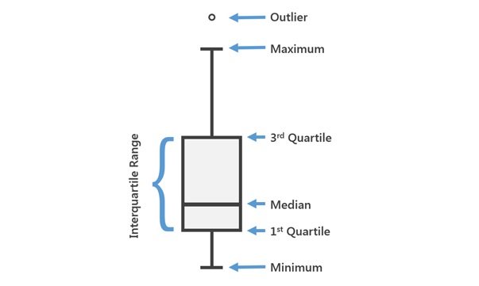

Boxplot explained

Let’s look at the relationship between the outcome and the categorical variable sex with a boxplot:

- From the main menu go: Graphs > Legacy Dialogues > Boxplot, then select Simple and click Define. Add the sbp variable into the Variable: box and sex into the Category Axis: box and click OK. What do you see?

In our sample males clearly tend to have moderately higher values of SBP than females on average, but both sexes have a broadly similar spread (i.e. approximately equal variance) of SBP values. We can also see that systolic blood pressure values in both groups appear to follow a fairly normal distribution, which you can tell this by the fact that the box plots are quite symmetrical, unlike the explanatory boxplot image above where the data would clearly be right skewed due to the larger spread of higher values. Asymmetry indicates a non-normal, skewed distribution with a higher spread of observations indicating right-skew and a lower spread of observations indicating left skew. You can always plot a histogram of the outcome within each group to understand this more clearly.

Again, you can now use these two types of plots to explore the relationships between all the other independent variables and the outcome if you wish, but there’s no real need to do this for this practical so feel free to move on.

## 14.5 Step 2: create the linear regression model

Video: create the linear regression model

Remember linear regression allows you to look at relationships between a numerical outcome variable and any number of numerical or categorical independent variables, assuming all the assumptions of the method are met (we’ll check these out shortly). So let’s see how we build, run and estimate our linear regression model in SPSS.

- From the main menu go: Analyze > General Linear Model > Univariate. Note: a univariate general linear model is essentially another name (less commonly used) for (multiple) linear regression, although confusingly SPSS also has various “regression” modelling tools as well that produce different linear regression model but with slightly different options available or (somewhat pointless) restrictions compared to this tool. One of the main benefit of the General Linear Model - Univariate tool is that you can add categorical variables without first converting them to dummy variables (see later for an explanation of what this means).
- Next in the Univariate tool we add our outcome variable sbp to the Dependent Variable: box. Then we add our independent variables. SPSS has separate boxes for numerical and categorical independent variables, so we add our numerical variables (bmi, salt and age) into the Covariate(s): box (you can highlight them all – hold shift while left-clicking – and add them together), and our categorical variables (sex, ses and ace) into the Fixed Factor(s): box (a factor is another term for a categorical variable). We can ignore the Random Factor(s): box and WLS Weight: box (see the help if you want to understand what they are for).

Next we need to edit a number of options. Most importantly we need to specify the “functional form” of our model or how the model is “parameterised”. Essentially we can either add all variables as simple “main effects”, which means the independent linear effect of each variable is estimated, or we can add additional terms to create interactions between two or more variables, and/or we can add non-linear terms for one or more variables. However, as interactions and non-linear terms are beyond the scope of this course we will just assume all our variables have simple linear relationships with our outcome.

- Therefore, click on the Model tool button, then under Specify Model select the Custom option, then select all variables in the Factors & Covariates: box (to do this click on the top variable, then click and hold shift before clicking on the bottom most variable). Next (with all variables still selected) change the drop-down menu under Build Terms(s) Type: to Main effects. Then click the right facing arrow beneath this menu which will add all selected variables as main effects terms into the Model: box. Ensure that the Include intercept in model box is ticked and click OK.
- Next click the Save button and under Predicted Values tick the Unstandardized box, and then under Residuals tick the Unstandardized box, and then under Diagnostics tick the box for Cook’s distance. This tells SPSS to save the unstandardised predictions and residuals, and values for “Cook’s distance”. We will explain these later.
- Lastly click the Options button, and then under Display tick the Parameter estimates box and click Continue and then OK. The output window will then pop up with the results, but first…

## 14.6 Step 3: check the assumptions of linear regression

Video: check the assumptions of linear regression

Before we look at the results that appear in the output window we must first check whether we can treat the results as robust and valid. Our results are only valid if the assumptions of the linear regression model have been met/hold, i.e. if they have not been violated. Below we’ll go through the assumptions and how to check them, which is more complicated than for the simpler statistical tests we ran previously.

**1. Continuous outcome**

Theoretically the outcome variable must be continuous, but like with t-tests this can be relaxed and you can safely use linear regression for discrete outcome variables as long as the other assumptions hold.

**2. Independent observations**

Technically this means that the residuals or model errors (variation not explained by the model) of one observation should not be correlated/related (be able to predict) to the residuals of other observations. As with the t-tests you should be able to understand from your study design whether you have independent observations or not. There are two main reasons for non-independent observations. 1) You have outcome measurements on your units of observation at more than one point in time (repeated measures) that are all included in the outcome variable. 2) You have outcome measurements on your units of observation that are nested within a larger cluster, such as patients within facilities, where patients from the same facility are going to be more similar and have correlated outcomes compared to patients from different facilities. We know our study design (simple random sampling of participants) ensures our observations are independent, so we don’t need to worry about this assumption further. What if your data are not independent? See below.

There are sophisticated and powerful ways of dealing with problems of non-independence, but we don’t go into them here. However, a simple solution for non-independent observations due to having multiple measurements across time is to just use observations from one time point only as your outcome (if this makes sense), or to take the average across all time points (if this makes sense), or to take the difference between your first and last time points and use these change scores as your new outcome (if this makes sense). And a simple solution for having non-independent observations due to clustering is to calculate summary values of the outcome based on all observations within each cluster. For example, if your outcome is a numerical variable, such as SBP, and you are looking at patients within facilities, then you can calculate the mean SBP across all patients in each facility, and then use the facility-level mean SBP as your outcome. For binary categorical variables (e.g. hypertension – yes/no) you can select one level (e.g. hypertension = yes) and calculate the proportion or percentage of observations in that level per cluster. For categorical variables with >2 levels you have to create separate summary percentage variables for each level.

**3. Normally distributed residuals**

Remember that in linear regression the residuals or model errors are simply the differences between each observed outcome value and the model predicted value (based on the linear regression equation). Technically the assumption here is “multivariate normality of residuals or errors”. In practical terms this just means checking that the residuals are (approximately) normally distributed, which luckily is easy to do. Linear regression assumes normally distributed errors, and if this assumption is violated then the resulting confidence intervals and p-values for coefficients can be biased (usually too narrow and too small respectively).

When we ran our linear regression using the General Linear Model – Univariate tool we told SPSS to calculate the “unstandardised” residuals for each observation and save them as a new variable, which SPSS will have called RES_1. To check whether the residuals are approximately normally distributed we could use a statistical test, but again this is sensitive to sample size and even if violated doesn’t necessarily mean our results won’t be robust, so it’s best to use a histogram.

- From the main menu go: Graphs > Legacy Dialogues > Histogram. Then add the RES_1 variable into the Variable: box, tick the Display normal curve box and click OK. What can you conclude?

The residuals appear to be reasonably approximately normal so we can safely assume this assumption has not been violated in our model. If the residuals were not approximately normally distributed then we can try to transform the outcome to increase the normality of their distribution. You can use the same methods as discussed and practiced in the “Inferential analysis 2: the independent t-test applied to a skewed outcome” practical, specifically see the “Step 2: transform the outcome” section.

**4. Linearity of the relationships between the residuals and all numerical variables**

Although you should have already confirmed the nature of the bivariate relationships between sbp and the numerical independent variables during your pre-modelling data exploration phase, once we are dealing with a multiple linear regression model it can be the case that once you adjust for a certain variable the adjusted relationship between another numerical independent variable and the outcome becomes non-linear. If this is the case the un-modelled non-linearity will be reflected in the residuals and cause bias in the inferential results (confidence intervals and p-values). Therefore, we must check whether the residuals show any non-linear patterns (curved trends) when plotted against the values of each independent numerical variable.

- We will use a scatterplot. From the main menu: Graphs > Legacy Dialogues > Scatter/Dot. Then select Simple Scatter and click Define. Add the RES_1 variable into the Y Axis: box and the age variable into the X Axis: box and click OK. What do you see?

There is no clear non-linear trend as the residuals are scattered fairly evenly and linearly across values of age.

In a real data analysis you should repeat this process for the other numerical independent variables in the model, but feel free to move on now if you wish because there are also no issues with the remaining variables. If you had found any non-linear relationships involving numerical independent variables then see the above “Bivariate exploration” section for a discussion of some possible solutions.

*5. Homoscedasticity: constant variance of the residuals across model predicted values**

The technical name for this assumption is homoscedasticity, but in practical terms this just means that there should be no systematic pattern or change in the amount of variation (i.e. spread) in the residuals across the model predicted values (also called the model fitted values). If the residual variance changes with predicted values (most commonly increasing at higher predicted values) then this is known as heteroscedasticity, and this can again lead to confidence intervals and p-values for coefficients can be biased (usually too narrow and too small respectively). Again there are statistical tests available to “test” for this, but we will use graphical methods. Again this is very easy to check: we just plot the model predicted values against the model residuals and hope to see “random noise”.

See the following three figures for an illustration of some examples of clear heteroscedasticity and homoscedasticity:

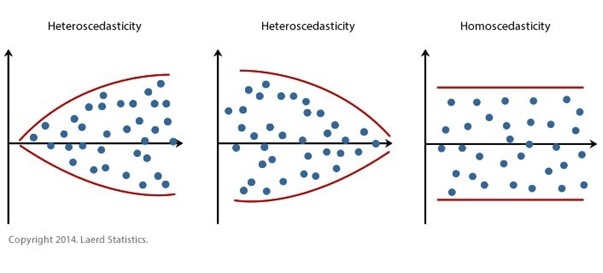

Illustrations of idealised heteroscedasticity and homoscedasticity residual patterns

Note: these are in an idealised/very clear form. You will often see some tapering of points at either end of the main spread of points because there is usually less data at these places, but this is not usually something to worry about.

Let’s now produce the necessary plot and check for violation of this assumption:

- From the main menu go: Graphs > Legacy > Scatter/Dot, then select Simple Scatter and click Define. Add the RES_1 variable into the Y Axis: box and the PRE_1 variable into the X Axis: box and click OK. Note: you can also get SPSS to make this graph via the Options menu in the General Linear Model Univariate tool, but it is a lot smaller and harder to see when made that way. What can we conclude?

The spread of the residuals looks fairly even across all values of the model predictions for the outcome, so we can safely assume this assumption has not been violated.

What if there had been a clear pattern in the residuals when plotted against the model predicted values?

The first thing to do would be to try and find out why this was. This is usually either caused by 1) having an outcome that covers a very large range of values, because typically the variance will be greater at larger values, even if the model is correctly specified, 2) having an outcome that varies more at higher/lower values of a numerical independent variable and/or varies differently between one or more categorical variable levels for whatever (genuine/real world) reason, or 3) having an incorrectly specified model, which means your model is either missing important and necessary non-linear and/or interaction terms, or is missing one or more independent variables that are important in explaining variation in the outcome.

Identifying scenario 2) and 3) involves exploring the relationship between the residuals and all independent variables in turn to try and identify the culprits, and careful thinking about whether any key independent variables may be missing from your sufficient adjustment set. While identifying scenario 1) involves ruling out scenario 2) and 3) and having an outcome with a large range of values (typically spanning a number of orders of magnitude).

How to solve this? If the problem appears to be due to scenario 3) you may be able to identify the culprit missing variable or missing functional form and update the model to solve the problem. If the problem involves scenario 1) or 2) then a simple and often sufficient solution is to use a linear regression model with “robust standard errors”, also known as “heteroskedasticity-consistent standard errors” or “Huber-White (robust) standard errors” (after the two inventors of the method). While we will not discuss or practice this solution further you can get an overview of how to run the method in SPSS here:

https://www.ibm.com/support/pages/can-i-compute-robust-standard-errors-spss

## 14.7 Step 4: consider additional possible issues

Video: consider additional possible issues

There are two additional common problems with linear regression models that, while not violations of any assumptions, can cause serious problems in obtaining valid/unbiased results.

**1. No serious multicollinearity**

Multicollinearity refers to the situation when one or more independent variables in your linear regression model are correlated with each other. If the correlation is weak, as exists between most independent variables, it’s not a problem, but when the correlation becomes very high this can cause problems with model estimation potentially giving you worthless results. We can test whether there is any substantial multicollinearity between our independent variables using the variance inflation factor (VIF) measure, which measures how much each variable inflates the estimates of its variance (standard error) due to its collinearity with one or more other independent variables. As a rough rule of thumb VIF values >10 are likely to be problematic for your results are need attention.

To get SPSS to estimate the VIF values for our independent variables we must re-run our model using the Regression tool. Unfortunately this tool does not allow us to include our categorical variables in their current form, and they must be manually converted into the necessary separate “dummy coded” or “indicator” variables for each level of each categorical variable (the General Linear Model - Univariate tool does this automatically “behind the scenes”).

What are dummy variables? To allow linear regression to model the effects of categorical variables we can use dummy variables. In the most common and simple coding scheme (see here for more on other coding schemes: https://stats.idre.ucla.edu/spss/faq/coding-systems-for-categorical-variables-in-regression-analysis-2/) we choose one level to be the reference against which the effects of all other levels are compared. Very briefly this level is then “omitted” and the mean of the linear regression model (when all other variables are set to 0) is the mean for the reference level. The remaining levels then have a dummy variable created for them, where the dummy variable takes the value of 1 if the observation is from that level or a value of 0 if the observation is from a different level. Dummy variables therefore act like “switches” that turn on or turn off the effect of each level when appropriate. Therefore, we must create dummy variables ourselves. To save time I have already done this.

- Therefore, to calculate the VIF values in the main menu go: Analyze > Regression > Linear. Then add sbp to the Dependent: variable box, and age, salt, bmi, sex_f_dummy, ses_m_dummy, ses_h_dummy and ace_dummy to the Independent(s): box (there is no dummy for sex = male or ses = low as these are taken to be the reference levels, i.e. the mean expected/predicted value of SBP when all independent variables have the value 0). Then click the Statistics button and tick the Collinearity diagnostics box. Click Continue then OK.

In the output window look for the “Coefficients” table. On the right hand side of this table you will see the two columns under “Collinearity Statistics” are labelled “Tolerance” and “VIF”. VIF is just 1/tolerance. Based on the rough rule of thumb what can we conclude?

There are no concerning signs of excessive multicollinearity for any independent variables. Great!

What if you do find excessive multicollinearity in your model?

What if one or more variables had very high VIF scores? Before doing anything we can actually ignore high VIF scores under some circumstances. 1) When they are only for “control” variables, i.e. variables whose effects we are not interested in interpreting but where we believe they need to be in our model because of our theory about the likely causal influences on our outcome. 2) Where the VIFs are for interaction or polynomial terms, because this is to be expected. 3) The variables with high VIF values are dummy variables for a categorical variable with three or more levels. When the reference level has an increasingly small proportion of the observations in it then the remaining levels will have increasingly large VIFs. You can avoid this by setting the reference category as a larger level. However, if the variable(s) with large VIF values aren’t covered by these situations then you need to consider why they have a high VIF. It means they are highly correlated with one or more other independent variables, which usually means they are essentially measuring the same thing. For example, weight and waist circumference will often be highly correlated. Therefore, in such a situation you can simply remove whichever one of the variables makes most sense for your research question.

**2. No extremely influential observations**

Sometimes single or multiple observations (individuals in our “SBP data final.sav” dataset) can have an excessive influence on the results, i.e. the coefficients and/or confidence intervals and p-values of your linear regression model, especially in smaller datasets. What this means is that including or excluding these observations from the analysis can change the results and potentially your overall interpretation of the results substantially. This is obviously not a good situation when the results are so sensitive to one or a few observations. If such observations exist in your model then you need to explore them and try and understand why they are so influential and whether they should be retained in the model. Observations can be influential in two main ways:

- Outliers: observations can have a large residual value, i.e. an outcome value that is unusually larger or small given its independent variable values.
- Leverage: observations can have values for one or more independent variables that are unusually large or small compared to all other values for that independent variable.

Separately or together these two processes can give rise to observations that are highly influential. There are quite a few ways to explore these issues, but for time and simplicity we will just look at one widely used approach: the Cook’s distance (D) statistic. Without going into details for each observation in a dataset Cook’s D measures “how much” the values in a regression model change when that observation is removed from the model. Cook’s D starts at 0 with higher values indicating more influential observations. Various rules of thumb have been proposed for judging when a value of Cook’s D indicates that the observation should be looked at, but these may fail, and it is simpler and probably more robust to just judge (based on the type of graph we will produce below) whether any observations have a value of Cook’s D that is relatively much greater than all the other Cook’s D values. We already told SPSS to calculate Cook’s D as a new variable in the General Linear Model Univariate tool when we selected the Cook’s distance option in the Save options.

The easiest way to explore which observations appear to have excessively large values for Cook’s D is to create a scatterplot of Cook’s D against the observation ID variable (which is just a simple count from the first to the last observation).

- Remember in the main menu we go: Graphs > Legacy Dialogues > Scatter/Dot. Then select the Simple Scatter option and click Define. Then add the Cook’s D variable COO_1 to the Y Axis: box and the id variable to the X Axis: box and click OK.
- Remember you can interact with an SPSS graph by double clicking on it. We can then click twice on an observation to highlight it alone with a yellow circle, which allows you to then right click and select “Go to Case” to see that observation in the Data View. What do you see on the graph?

Two observations appear to have clearly relatively much higher values for Cook’s D than all the other observations. Interacting with the graph we can explore these observations, which have ids of 478 and 520.

What do you notice about the outcome and/or independent variable values for these observations?

Observation id 520 has a very large value for BMI of 41, but otherwise appears normal, so this is likely driving its influential power. While observation 478 has a very large value for the outcome, with a SBP of 175, but otherwise has fairly “normal” values for its independent variables although they are of high socio-economic status and taking an ACE inhibitor, both of which (as we’ll see) are associated with lower values of SBP in the sample, so this is likely driving its influential power.

What should we do? Generally unless you can be certain that an observation is influential due to an error in the outcome or an independent variable then you should not make any changes to these values nor should you exclude the observation from your primary analysis. However, a simple, transparent and widely recommended approach is to conduct a sensitivity analysis by removing such observations from the dataset (i.e. create a copy of the dataset and then delete them entirely) and re-running your analysis to see if the results change substantially. If the results do not change in any important way then you should report this lack of change following the removal of the observations, but include the sensitivity analysis results in an appendix etc so readers can verify the truth of this. If the results do change substantially then it makes most sense to report both sets of results in the main paper and interpret accordingly, i.e. be clear that the conclusions change depending on whether such extreme observations are included or not. Either way you must be transparent and open about their effects.

## 14.8 Step 5: understand the results tables and extract the key results

Video: understand the results tables and extract the key results

So now that we have verified that our results are robust, and the assumptions of the model hold, we can finally interpret our results. This is the really interesting and exciting part of any analysis! As you’ll have filled the output window with lots of graphs from the assumptions checking you may wish to re-run the linear regression again. Either way in the output window the results are presented in three tables.

The first table “Between-Subjects Factors” isn’t that useful (assuming we understand our data well), and just shows the number of observations in each level of each categorical variable. The second table “Tests of Between-Subjects Effects” shows an “ANOVA” table. This can be used to understand the “statistical significance” of each term (but only the overall term for categorical variables, not each level) in relation to how much variation it accounts for in the outcome variable. However, this is arguably of little value when our final table “Parameter Estimates” (which SPSS doesn’t provide by default!) provides us with both an estimate of the “statistical significance” (i.e. the p-value) of all terms including categorical variable levels, but also much more usefully it gives us the linear regression coefficient (i.e. the estimated direction and size of the relationship) and its 95% confidence interval for every independent variable (or more specifically every term) in the model. Therefore, we will largely ignore the second table (apart from coming back to one piece of information it provides that should really just be in the “Parameter Estimates” table), and just focus on the “Parameter Estimates” table.

So what does it all mean?

**Parameter estimates table columns explained**

**Parameter**

- Each row indicates which term in the model the following results apply to. Terms are either the intercept or (in our case) main effects of independent variables, or with more complicated models they may include interaction terms and/or non-linear terms like polynomial terms. For numerical variables this means one row per variable. However, because each level of a categorical variable is actually treated as a separate “dummy variable” (coefficient) as standard in a linear regression model each categorical variable level has its own row.

**B**

- B stands for “betas”, because in the linear regression model when represented mathematically the coefficients are usually represented by the Greek letter beta. The betas are more commonly referred to as the linear regression parameter estimates or coefficients. They tell us the best estimate (point estimate) of the direction (positive or negative) and size of the relationship between each parameter in the regression model and the outcome variable.
- For all numerical independent variables they represent the expected mean change in the outcome variable for every 1-unit increase in the independent variable.
- For categorical variables it’s a bit more complicated. There are many different ways of looking at categorical variable effects, but the most common is called dummy coding, and this is the default presentation in SPSS and most (probably all) stats software. With dummy coding one level in the categorical variable (e.g. female in the variable sex) is set as the reference level. Then the coefficients for the other level(s) represent the expected mean difference in the outcome variable between each level and the reference level (e.g. male compared to female). Unfortunately (for no obvious reason) SPSS’s univariate general linear model tool does not display value labels for categorical variables in the “Parameter Estimates” table and so all you see are the numerical codes (you’ll have to check the value labels in the Variable View if you can’t remember the value coding). By default SPSS sets the level with the highest value as the reference level. You will notice that the reference level always has a coefficient value of 0, with a superscript letter “a” linking to a footnote explaining that “This parameter is set to zero because it is redundant”, i.e. it’s the reference level.
- A note on the intercept. You may be wondering what the “Intercept” parameter represents? In a simple linear regression with just one independent variable this corresponds to the Y-intercept (hence the name), i.e. where the linear regression line crosses the y-axis (and the independent variable or x-value is 0). In a multiple linear regression this represents the expected/model predicted mean value of the outcome when all numerical independent variables have a value of 0 and all categorical variables are at their reference levels. Therefore the intercept will rarely have any useful interpretation (e.g. it assumes BMI = 0) and is usually ignored as a necessary but informative structural part of the model (unless you centre your variables, which we will not be looking at here).

**Std. Error**

- This is the standard error of the coefficient, which is an estimate of the sampling variability of the coefficient in the target population. This is used when calculating the 95% confidence intervals and p-value, but you can ignore these and just interpret the 95% confidence intervals and (if you wish) p-values.

**t**

- This is the t-statistic for the coefficient and is used when calculating the confidence intervals and the p-value associated with the coefficient. You can calculate 95% confidence intervals and p-values assuming normally distributed data, but using the t-distribution is more conservative (safe) for small sample sizes and is equal to assuming normally distributed data at large sample sizes. You can ignore these and just interpret the 95% confidence intervals and (if you wish) p-values.

**Sig.**

- This is the two-tailed (although now it doesn’t mention that explicitly!) p-value associated with each coefficient. Again, assuming the “true” value of the coefficient in the target population is 0, the p-value represents the probability of observing a coefficient at least as great as that observed (positively or negatively as it’s a two-tailed p-value) due to sampling error alone.

**95% Confidence Interval (Lower Bound and Upper Bound)**

- These are the lower and upper 95% confidence intervals for the coefficient based on the t-distribution. As usualy, loosely speaking they represent a range of values that we can be reasonably confident contain the “true” coefficient that exists in the target population.

Then lastly if we go back to the “Tests of Between-Subjects Effects” table and look at the footnotes we see one footnote: “a. R Squared = .594 (Adjusted R Squared = .588)”. In a linear regression model the R² value represents the proportion (or % if you multiply it by 100) of variation in the outcome variable that is explained by the model, i.e. by all the terms of variables in the model. However, whenever you add a term to a model the R² value will increase even if the term is a random number variable, and has no true explanatory power for the outcome. Therefore, it is better to use the adjusted R2 value which makes a correction for the number of variables in the model. Note, R² values in health sciences are rarely as high as the one seen here, which is due to the artificial nature of the data.

Therefore, typically we are just interested in the key descriptive statistics about the sample (number of observations and missing values, which are more easily obtained via separate descriptive analysis of the dataset), and in terms of the inferential results we want the parameter or coefficient estimates, their associated 95% confidence intervals (and possible their associated p-values), and often also the R² value of the model.

## 14.9 Step 6: report and interpret the results

Video: report and interpret the results

### 14.9.1 Numerical variables

First we’ll look at how to interpret the results relating to the numerical independent variables and their relationship with the outcome statistically and then how to interpret that result in practical terms (sometimes referred to as the results’ statistical and practical significance).

**Statistical interpretation**

> For numerical independent variables linear regression coefficients represent the model-predicted mean (or more loosely the average) change in the outcome (i.e. in units of the outcome) for every 1-unit increase in the independent variable’s units, while holding the effect of all other independent variables constant, i.e. they measure the mean independent relationship. Note: this change does not depend on the value of the independent variable, i.e. the same relationship is assumed to exist across the full range of values that the independent variable can take in the sample data, but it should not be considered to hold if you were considering values of the independent variable outside of the range of values seen in the sample data.

Let’s take age as an example. Looking at the parameter estimates table the point estimate (i.e. the single best estimate) of the regression coefficient is 0.21. This means that, based on the model, the point estimate of the relationship between age and systolic blood pressure in the target population is that for every 1-unit increase in age, i.e. for every year older a participant is, the model predicts that an individual’s systolic blood pressure will increase by a mean of 0.21 mmHg, whilst holding the effect of all other independent variables constant (i.e. this estimated relationship is independent of the effect of all other independent variables in the model).

However, how sure can we be about the true direction and size of the regression coefficient (i.e. the relationship of interest) in the target population given our sample size and the sampling error in the sample? This is what our confidence intervals help us to estimate. Remember, formally they provide a range of values that, hypothetically speaking, if we were to repeat our study and analysis many times (technically an infinite number of times), would contain the true value of the regression coefficient in the target population X% of the time, where the true value of the regression coefficient would be the value of the regression coefficient that we would get if we measured every individual in our target population and ran the model, and X% is the confidence level (typically 95%). Informally and more loosely speaking a 95% confidence interval around a regression coefficient gives us a range of values that we can view as likely including the true value of the regression coefficient that exists in the target population (but we can’t say within that range which values are more/less likely).

Therefore, in the parameter estimates table we can see that the 95% confidence intervals for the regression coefficient for age are 0.03 and 0.39. Consequently, we can be reasonably confident that the true value of the regression coefficient in the target population is between 0.03 and 0.39. And so because the 95% confidence intervals are fairly narrow we can conclude that we have obtained a reasonably accurate estimate of the likely relationship between age and systolic blood pressure in the target population. However, as always this is assuming there is no bias in the results, which in a real study is very unlikely, and therefore in a real study we must consider all likely sources of bias and their likely impacts when assessing the inferential results!

**Practical importance**

Now we know how to interpret the result statistically how do we interpret its real-world practical importance? For example, what can we conclude about its importance clinically and for public health programmes? These are complicated questions that have no simple answers and different people will have differing views depending on their views of the evidence (result) and the wider context. Most importantly you need to think carefully and critically and have strong subject matter knowledge to make robust interpretations and suggestions/recommendations. However, we can give some guidance about things to consider. You should clearly consider whether individuals or other units of observation can have their values of the independent variable of interest moved or not, and what this implies for what clinical practice and public health programmes etc can or cannot do about that the characteristic represented by that independent variable. For example, an individual cannot alter their height, while their age changes but out of their control, but their weight can be affected by themselves or outside influences (e.g. interventions).

For numerical independent variables we must then also consider what range of values most individuals (or units of observation) take in the study/sample. This is because the impact of a 1-unit increase in an independent variable can add up if that variable can increase by many units. For example, our regression coefficient for age is 0.2 (95% CI: 0, 0.4) (rounding up for ease subsequent example calculations), and the age range in the study/sample was ~40 years. Therefore, across our age range, which most individuals will “experience”, based on the 95% confidence interval ranges for age, age is expected to account for a mean increase in individuals’ systolic blood pressure of between 0 x 40 = **0 mmHg** and 0.4 x 40 = **16 mmHg**. Note: unless strongly justifiable you should not interpret your results outside of the range of the independent variables in your sample, e.g. you should not try and interpret the age relationship as holding for individuals aged between 70 and 80 as no such individuals were in the study.

Therefore, it might be reasonable to say that while every extra year makes little difference to most individuals’ systolic blood pressure, across forty years of their life it may result in a clinically important increase, which might therefore be of importance when considering relevant clinical guidelines and public health programmes. However, as noted earlier practical interpretations are complicated and you should consider all relevant contextual issues. For example, an increase of 16 mmHg or more systolic blood pressure may not make any clinical difference for a health individual, but a smaller increase might be very clinically important for someone with cardiovascular disease.

### 14.9.2 Categorical variables

**Statistical interpretation**

> With the standard dummy coding of categorical variables (https://stats.idre.ucla.edu/spss/faq/coding-systems-for-categorical-variables-in-regression-analysis-2/) linear regression coefficients represent the model-predicted mean (or more loosely the average) difference in the outcome (i.e. in units of the outcome) between the categorical level (or group) of interest and the reference or comparison level (or group), while holding the effect of all other independent variables constant, i.e. they measure the mean independent relationship. The choice of which categorical level is set as the reference group is up to you.

Let’s take socio-economic status as an example. Looking at the parameter estimates table as this is a categorical variable there are separate rows for each of the levels of ses. First we can see that the highest value of ses (3), which codes for high socio-economic status, has been set as the reference group and has a regression coefficient of 0 (“ses=3” has a *B* or regression coefficient of 0). This means that the regression coefficients for the other socio-economic status groups represent the difference in the outcome in relation to/compared to the high status group.

Look at the coefficients for “ses=1” and “ses=2”. Here we can see that participants with a low socio-economic status (ses=1) have a point estimate regression coefficient of 7.91. This means that, based on the model, the point estimate of the mean difference (or relationship) in systolic blood pressure between individuals in the low socio-economic status group compared to individuals in the high socio-economic status group, in the target population, is 7.91 mmHg, whilst holding the effect of all other independent variables constant (i.e. this estimated relationship is independent of the effect of all other independent variables in the model). To clarify, this means that the model estimates that in the target population individuals in the low socio-economic status group have systolic blood pressure values that are on average 7.91 mmHg higher than individuals in the high socio-economic status group, while holding the effect of all other independent variables constant. We would interpret the result for the medium socio-economic status group similarly.

Then as with the numerical independent variables we of course need to look at the 95% confidence intervals to judge the likely direction and size of relationship in the target population, given our sample size and sampling error (i.e. our point estimate is not necessarily very precise). From the parameter estimates table we can see that the 95% confidence intervals for ses=1 are 4.85 and 10.97. Therefore, we appear to have a reasonably precise/clear estimate of the effect of low socio-economic status compared to high socio-economic status, and it appears that being of low socio-economic status compared to high socio-economic status is independently associated with slightly higher systolic blood pressures on average.

**Practical importance**

As with numerical independent variables interpreting the practical or real-world importance is complicated and requires careful and critical thought and strong subject matter knowledge. Similar to interpreting the practical importance of numerical independent variable results you should consider things like the relative proportions of individuals or other units of observation in your different categorical variable levels, and how plausible it is that individuals or other units of observation can move or be moved between category levels, say via interventions. Again you should also not interpret the results for category levels not in your sample, or for comparisons between category levels that you did not formally make.

### 14.9.3 “Non-significant” results

Note: you should present and discuss all results, i.e. “non-significant” results too, which may have equal if not more importance in relation to your research question. However, take care. A common mistake in interpreting inferential results is to treat a non-significant result as indicating “no difference” or “no relationship”, when actually the correct interpretation is that it provides no clear evidence of a difference or a relationship, but there may well be a real difference or a relationship in the target population but it’s just that it may be too small for you to have had much chance of detecting it with your dataset. In terms of whether a difference/relationship exists in the target population, there are actually typically three possibilities when you find a non-significant difference/relationship in your sample dataset:

1. There is really no (or negligible) difference/relationship in the target population.

2. There is a difference/relationship in the target population but it is too small for you to have any real chance of detecting it with your sample size (i.e. you lacked statistical power), no matter how many times you repeated the study.

3. There is a difference/relationship in the target population and given its size and your sample size you had a good (e.g. >80%) chance of detecting it, but due to sampling error or other sources of bias you did not find any evidence of it in your single dataset. If you repeated the study lots of times though you’d find statistically significant evidence for it more often than not.

There are analysis methods (e.g. “power calculations”) to help you get an idea about which of these possibilities is most likely, but as they are beyond the scope of this introductory course and actually not commonly used we will not look at them further.

### 14.9.4 Regression tables

When reporting the results from a linear regression model it is common to use a table to present the results, given there are typically a large number of results of interest. The following tips/recommended best practices may be useful when creating regression results tables:

- Separate 95% CI lower and upper values with a comma, not a dash (-), otherwise negative values can be ambiguous or hard to read.
- You can refer to the reference level in other ways, but the above is a simple and clear approach.
- P-values <0.001 are usually referred to as such without further decimal place values.
- Always include all units for numerical variables.
- Always ensure the outcome variable is clearly mentioned (here in the title) along with the units it’s measured in.
- Include the adjusted R² value.

In the exercise below you can fill in a regression results table “template” that incorporates these features, so you can then use this template/format to guide your future presentation of regression results.

### 14.9.5 Methods

As usual in a methods section you should clearly explain why you used a linear regression analysis and exactly what you did, including how all the variables were coded/what units they were in, if you modified any variables, how you dealt with any missing data etc.

## 14.10 Exercise: multiple linear regression

- In the YCHI5045M computer sessions materials “Exercises” folder open the “Exercises.docx” Word document and scroll down to **Multiple linear regression: the causes of variation in systolic blood pressure**. Then follow the instructions in the exercise.

Example completed linear regression results table:

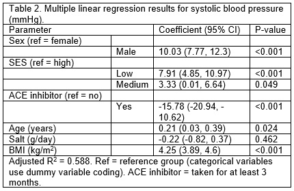

Linear regression results table

Example statistical and practical interpretation of the relationship between BMI and systolic blood pressure:

There was a clear and precise, statistically significant relationship between BMI (kg/m²) and systolic blood pressure (mmHg) in the linear regression model, indicating that for every 1-unit increase in BMI there is a mean increase in systolic blood pressure of 4.25 mmHg (95% CI: 3.89, 4.6) independent of all other independent variables. Given that the range of BMI in the study was 23, the relatively narrow confidence intervals for this relationship indicate that variation in BMI has the potential to have a very substantial impact on variation in systolic blood pressure in the target population, and given BMI is potentially variable by individuals and interventions this has clearly important clinical and practical implications. For example, this result suggests an increase in BMI of just 10 could potentially lead to an increase of between 39 mmHg (3.9 x 10) and 46 mmHg (4.6 x 10) in an individual’s systolic blood pressure on average, implying this should be considered when developing treatment guidelines and public health programmes.

Example statistical and practical interpretation of the relationship between sex and systolic blood pressure:

There was a clear and precise, statistically significant relationship between sex (male/female) and systolic blood pressure (mmHg) in the linear regression model, indicating that compared to females males had systolic blood pressure values that were on average 10.03 mmHg (95% CI: 7.77, 12.3) higher, independent of all other independent variables. Therefore, considering that the mean difference is likely to be between 7.77 mmHg and 12.3 mmHg this appears to be a potentially important clinical difference that should be considered when developing treatment guidelines and public health programmes (for example, by educating males on their higher risk of having higher systolic blood pressure).

Example text discussing the key limitations of the study and the issues that must be considered when critically interpreting the results:

Care must be taken when interpreting the results because the study was an observational cross-sectional study with therefore very limited ability to make robust causal inferences, and because the validity and accuracy of the results depends on how well the study data and model have accurately captured the causal relationships of interest and all important confounding variables of those causal relationships, and on how much bias there was in the study.

## 14.11 Next steps (optional)

- If you have time why not run the sensitivity analysis for the extremely influential observations? Simply remove them from the dataset (go to the Data View and right click on their observation number on the left of the screen to highlight the relevant row, then select “Clear”), re-run the model and compare the results to those above.
- Confirm to yourself that an independent t-test is equivalent to a simple linear regression with one binary independent variable: using the “SBP final data.sav” dataset run an independent t-test analysing the difference/relationship between sex and systolic blood pressure, and then run a linear regression with systolic blood pressure as the outcome and sex as the sole independent variable. You should see that the coefficient estimate from the linear regression matches the mean difference estimate from the t-test, and the 95% confidence intervals and p-values match as well. Underlying the independent t-test is a model that is equivalent to a simple linear regression!

# 15 Multiple logistic regression

## 15.1 Overview

Like linear regression logistic regression allows us to analyse the relationships between any number of continuous and/or categorical independent variables and an outcome , but unlike linear regression the outcome in logistic regression must be binary. Like with linear regression “simple logistic regression” may be a term used to refer to logistic regression with one independent variable only, while “multiple linear regression” refers to including more than one independent variable, but there’s no qualitative difference, and we’ll just refer to “logistic regression” from here on.

You can actually analyse binary outcomes using linear regression, and you will sometimes see such analyses in the literature (sometimes called a “linear probability model”) and you can often get reasonably useful (i.e. reasonably accurate/unbiased) results. However, generally this is not recommended because of the often substantial disadvantages and problems with this approach. For example, the model predictions may range outside 0-1 (the only values your outcome can take in reality when viewed as a probability of the event occurring), and your inferences are likely to be biased because the assumptions of linear regression cannot be met in such a situation, producing biased confidence intervals and p-values. Although logistic regression is more complex mathematically the basic idea of creating a linear model (where the terms are additive) with numerical or categorical independent variables is the same, although the interpretation of the terms differs substantially.

## 15.2 Scenario

We will use almost exactly the same scenario as for the linear regression practical. Namely, we wish to understand the likely causes of variation in individuals’ *hypertension status* (rather than their systolic blood pressure), where we define hypertension as having a systolic blood pressure ≥140 mmHg, using the data collected in the SBP dataset. Refer to the “The datasets” section within the “Introduction to SPSS” section for full details if you need a full reminder, but briefly this dataset contains data on 556 individuals who were (hypothetically speaking!) sampled in a cross-sectional survey, and had data collected on their systolic blood pressure plus certain socio-demographic (age, sex, socio-economic status) and health characteristics (BMI, salt intake and ACE inhibitor usage).

## 15.3 Modelling process

We will use an almost identical modelling process to that used in the linear regression practical, loosely following a causal inference inspired approach, but in practice for simplicity building one model and interpreting all the independent variables causally. As discussed in the “Overview with a focus on causal inference from observational data” section in the “Inferential analysis 5: multiple regression” section, we will assume, based on existing theory/evidence and plausible, critical thinking, that all our measured independent variables are all likely causes of variation in individuals’ hypertension status, which collectively simultaneously act as a sufficient adjustment set when interpreting each independent variable’s relationship with the outcome causally. That is, we will just create one logistic regression model containing all the independent variables and assume that this model represents the same sufficient adjustment set for each independent variable (i.e. when interpreting the effect of each independent variable causally we will assume all other variables in the model are confounders of that relationship that require adjusting for to obtain an unbiased estimate of the focal causal effect). In reality if we were doing this we should start by deciding which focal relationships of interest we were interested in, which may well not be all of our collected independent variables, and for each focal relationship of interest we should define a sufficient adjustment set which may well differ from the sufficient adjustment set of other focal relationships of interest. This would typically be a big and time consuming process requiring a lot of careful critical thought and research/subject matter knowledge.

## 15.4 Step 1: explore the data

Video: explore the data

The same basic reasoning applies to our data exploration process as with the linear regression modelling process, so refer back to the “Step 1: explore the data” section in the linear regression practical if you want a reminder of the theory/justification for the following data exploration process.

In practical terms though we would examine the distribution of each variable on its own using the same methods discussed in the linear modelling practical, but when examining the relationships between the outcome and each independent variable we would have to use different graphical approaches.

**Numerical independent variables**

Specifically, as we have a binary outcome when exploring the relationship between numerical independent variables and our binary outcome we have to use a form of barchart, where we first create a “binned” or grouped version of our numerical independent variable (i.e. a new variable which takes a single value for a range of values of the original independent variable).

Let’s see how to do this for bmi. First create the binned independent variable.

- From the main menu go: Data > Visual Binning. Add bmi to the Variables to Bin: box and click Continue. At the top of the window that apppears look for the Name: fields and in the editable field called Binned Variable: give your new binned variable a name, e.g. bmi_bin. Then at the bottom right click on the Make Cutpoints… button. In the middle of the tool window click the Equal Percentiles Based on Scanned Cases option and in the Intervals - fill in either field are click on the Number of Cutpoints: box and enter a suitable number of cutpoints. It’s hard to know what is a suitable number but typically the more bins the better, as you can see relationships at a finer scale, but for more bins you need more data (sample size). For bmi let’s choose 15, but you can always remake this variable with more/fewer bins as needed. Therefore, enter 15 in this box and then click Apply at the bottom. Then click the Make Labels button just below the Make Cutpoints… button and then click OK. Click OK on the information box that appears.

Now we can plot the mean of our binary outcome, which is equivalent to the proportion/percentage, for every bin we’ve just created, using a type of barchart, although we’ll use a “histogram” tool to create it.

- From the main menu go: Graphs > Chart Builder. If an information box appears saying “Before you use this dialogue…” just click OK. Now in the Gallery tab at the middle left click on Histogram and then double click on the leftmost picture of a graph (Simple Histogram) to add it to the plot. Next drag the htn variable from the Variables: box onto the Y-Axis? dotted box on the chart image. Similarly, drag the bmi_bin variable onto the X-Axis? box. Look to the right of the tool window at the Element Properties tab in the Statistics box. You should see a drop down menu under Statistic:. This should already read “Mean”, but if not click on it and select mean. This tells SPSS to calculate the mean of the Y-axis variable, htn, for each value of the X-axis variable, which are now repeated when in each bin. Now just click OK.

What can you see?

There appears to be a fairly linear increase in the proportion of individuals with hypertension as BMI values increase.

**Categorical independent variables**

For exploring the relationship between categorical independent variables and binary outcomes we can just use a normal barchart where the Y-axis is the proportion of the outcome in each category level on the X-axis. Let’s see how to do this for sex:

- From the main menu go: Graphs > Chart Builder. If an information box appears saying “Before you use this dialogue…” just click OK. Now in the Gallery tab at the middle left click on Bar and then double click on the top leftmost picture of a barchart (Simple Bar) to add it to the plot. Next drag the htn variable from the Variables: box onto the Y-Axis? dotted box on the chart image. Similarly, drag the sex variable onto the X-Axis? box. Look to the right of the tool window at the Element Properties tab in the Statistics box. You should see a drop down menu under Statistic:. This should already read “Mean”, but if not click on it and select mean. This tells SPSS to calculate the mean of the Y-axis variable, htn, for each value of the X-axis variable, which are now repeated when in each bin. Now just click OK.

What can you see?

Men appear to have roughly twice the proportion of hypertension cases compared to women.

In a real analysis you would explore all bivariate relationships this way, but as with the linear regression practical feel free to move on once you are happy with the process.

**Cell frequencies**

Unlike with linear regression we have one more data exploration process that we must do. When looking at relationships for a logistic regression model an important issue to look out for is so-called “sparse data”, which means we have small (or empty) “cell sizes”, which really means few (or no) observations of one of the levels of our binary outcome (e.g. either htn = yes or htn = no) in one or more levels of one or more categorical variables (e.g. if say all men were classed as htn = yes). This is explained in more detail during the “Additional potential problems” section below, but briefly if there are zero observations of one outcome level within one or more independent categorical variable levels that will cause the model to fail. If there are just a few you may see very large biased coefficients and confidence intervals. How few is few? There’s not set number, but <5 is often a cause for concern.

We can explore this issue using cross tabulations of the outcome variable against the categorical independent variables.

- Go: Analyze > Descriptive Statistics > Crosstabs. Add htn to the Row(s): box and sex, ses and ace to the Col(s): box then click OK.

This will give us three tables, one for each categorical variable. Look at each cross-tabulation cell to see the number of observations in that cell, i.e. each possible combination of the independent categorical variable’s level and the outcome’s level, which for sex vs htn would include 1) male-yes, 2) male-no, 3) female-yes, and 4) female-no. What can you see?

There appear to be reasonable numbers of observations of both levels of the outcome for all levels of sex and ses, but ACE = yes has only three htn = yes observations. See the “Additional potential problems” for more discussion of the possible problems this might cause.

## 15.5 Step 2: create the logistic regression model

Video: create the logistic regression model

We will use SPSS’s Generalized Linear Model tool to build our logistic regression model. The generalised linear modelling framework is a more comprehensive and coherent way of (mathematically) representing the full range of possible regression type models, of which linear regression and logistic regression are specific types. SPSS somewhat confusingly and redundantly also has a Binary Logistic tool under the Regression menu, which will also create a logistic regression model, but like the Linear (Regression) tool in the Regression menu it is also more restrictive because it won’t accept categorical variables without us first converting them to separate dummy variables, and it also does not offer all the options available in the Generalized Linear Model tool.

- From the menu go: Analyze > Generalized Linear Models. This will open the Generalized Linear Models tool which has multiple tabs along the top of the window.
- In the first tab Type of Model look for the “Binary Response or Events/Trials Data” set of options and select Binary logistic. This tells SPSS we want to create a logistic regression model from among the many other possible generalised linear models (note: linear regression is also a specific type of generalised linear model, and could be run from this tool via the “Scale Response” Linear option).
- Then click on the Response tab and add the htn variable to the Dependent Variable: box. Then click on the Reference Category… button and under “Reference Category” select First (lowest value), which sets the lowest value in the htn variable, 0, as the reference category (i.e. htn = no as the reference category) and click Continue (without recoding the outcome variable by changing this option we could make our results refer to the likelihood of not having hypertension if this suited our needs better).
- Then click on the Predictors tab and add the categorical variables sex, ses and ace into the Factors: box and the numerical variables age, salt and bmi into the Covariates: box.
- Then click on the Model tab and highlight all the independent variables in the Factors and Covariates: box (click on the top one, hold down shift and then click on the bottom one). Then under the “Build Term(s)” options ensure the Type: is set to Main effects (this should be the default) and click the right facing arrow to add the variables into the Model: box.
- We will ignore the Estimation tab and just accept its defaults (this is where you can alter how the model is estimated.
- Next click on the Statistics tab and in the “Print” options tick the Include exponential parameter estimates box.
- Lastly click on the Save tab and tick the boxes for “Predicted value of mean response”, “Cook’s distance” and the “Standardized Pearson residual”. The predicted value of the mean response is the model predicted probability (i.e. a value between 0 and 1) for each observation given the values of its independent variables. The Cook’s distance is calculated differently than for a linear regression but again measures how much effect each observation has on the regression coefficients. The standardised Pearson residual is one possible type of residual that can be calculated for a logistic regression model, which allows us to see how much of a difference there is between model predicted values and the observed outcomes.
- Finally click OK.

As with the linear regression practical, before interpreting the results we should check the assumptions of the model are not violated, and if they are make any necessary changes before re-running the model.

## 15.6 Step 3: check the assumptions of the logistic regression

Video: check the assumptions of the logistic regression

Unlike with linear regression logistic regression has fewer assumptions and they are not all easily checked. Specifically, logistic regression no longer assumes linearity in the relationship between the independent variables and the outcome, nor does it assume normality or homoscedasticity in the residuals. However, it does have some assumptions as discussed below.

**1. Binary outcome**

Self-explanatory! However, note that we can code the variable either way around depending on whether we want our results in relation to the likelihood of observing a given “event” or the “non-event”. For example, for our hypertension variable we could obtain results in relation to the likelihood of having hypertension or of not having hypertension if we coded the outcome as 1 = hypertension or 1 = not hypertension respectively, or equivalently we can use the relevant SPSS model building options as explained in the “Step 2: create the logistic regression model” section to change the reference level.

**2. Independent observations**

As with linear regression logistic regression assumes observations are independent of one another, which we can assume for our study data here as it came from a simple random (cross-sectional) sample. However, if our study design implies this is not the case then we need to either use a method that can cope with this (beyond the scope of this course) or modify our data.

The alternatives aren’t exactly the same as for linear regression though. For longitudinal (multi-time point) data we can again use logistic regression if we just use data from one time point. However, unlike with linear regression we cannot calculate a change value between two time points and analyse that with logistic regression because outcomes of 0-0 and 1-1 at two time points will both give us the same change score, but mean very different things. Similarly if we have nested or clustered observations, such as patients within clinics, we cannot calculate summary outcome values for each cluster, such as means, and use logistic regression as the values will no longer be binary. We may however calculate the proportion of events per cluster and, assuming the assumptions are met, use linear regression to analyse this cluster-level summary (proportion) outcome. Like with linear regression there are multi-level logistic regression models that can explicitly model clustered (or multi-level) data.

**3. Linearity of relationships between the log-odds and numerical independent variables**

This is similar to the linear regression linearity assumption, but differs in a key way. With logistic regression the model estimates the predicted log-odds of the outcome rather than the actual value of the outcome (0/1), also called the logit transformation of the outcome, for each observation (e.g. individual), given/conditional on the values of the independent variable(s) for that observation. The logistic regression model assumes that there is a linear relationship between any numerical independent variable(s) and the log-odds of the outcome variable. In theory we can test this by looking at the relationship between the residuals and the predicted/fitted values or numerical independent variables, but the resulting plots can be difficult to interpret usefully as you can still get curved patterns but due to the nature of logistic regression not have a model that has violated this assumption. See the following for more discussion:

- https://stats.stackexchange.com/questions/121490/interpretation-of-plot-glm-model
- https://stats.stackexchange.com/questions/45050/diagnostics-for-logistic-regression

Hence, we won’t produce such plots here and instead recommend that you think very carefully about the model you are building in terms of whether you have allowed for any strong/important non-linear relationships and/or interactions that evidence suggests may be present.

## 15.7 Step 4: consider additional problems

Video: consider additional problems

**1. Adequate sample size**

Although you should always consider your sample size when conducting any statistical analysis logistic regression requires more data than a hypothetically equivalent linear regression to achieve the same level of precision in its estimates, because there is less statistical information in an outcome than can only take two values. There are various rules of thumb. A common one is having at least 10 observations (e.g. individuals) that have the *least frequent outcome* (i.e. that either have the event or do not have the event of interest, depending on whether having the event or not is more common in the sample) for each independent variable in your model. For example, if you have three independent variables and the overall proportion of your least frequent outcome, say not having hypertension, is 0.1, then you would need a minimum sample size of (10 x 3) / 0.1 = 300. All such rules are just rough guides, and it doesn’t mean you can’t build a model with less data, but they give you a good idea about the likely amount of data you need for decent precision. If you do have a much smaller sample size than these guides you’ll typically find you have very wide confidence intervals for all your coefficients, making meaningful inference difficult, and it increases your chances of getting “sparse data” or “complete separation” (see next).

**2. No complete separation/sparse data**

Complete separation refers to the situation when one or more levels of one or more categorical variables levels have 100% 1s or 100% 0s observed for the outcome (e.g. every male had “hypertension” or did not have “hypertension”). In such a situation a standard logistic regression model cannot estimate the coefficient or standard error for that categorical variable level because there is no statistical variation in the outcome. The solutions are: 1) remove the entire variable, or 2) if possible recode the variable so that you “collapse” or merge two or more category levels together so that all levels have at least one (ideally more) of each possible observation (i.e. a 1 or a 0), but the newly merged category levels must make logical sense for this to be a viable solution.

Sparse data refers to the situation where there are very few 1s or 0s observed in the outcome variable in one or more levels for one or more categorical variable levels (also referred to in this context as “cells”, e.g. the male and female cells for the variable sex). In such a situation with a standard logistic regression model the estimated coefficients and/or standard errors for that categorical variable level will often be very large and biased.

We checked the cell counts for each level of the outcome in the data exploration stage and found there were only 3 htn = yes observations in the ace = yes cell. There are rules of thumb for judging if a cell has sparse data, but really it’s often easiest to just run the model and look at the results and if problems have occurred you will see extremely large (positive or negative) coefficient(s) and standard errors/confidence intervals. You can also check the cell counts for sex and ses if you wish, and you should do this for all categorical variables in a real data analysis situation, or you can move on as we know from earlier data exploration that they are fine.

**3. No serious multicollinearity**

Again if there is substantial multicollinearity between two or more independent variables this can cause serious problems with the model’s ability to accurately estimate the results. As we are only looking at correlations between the independent variables when assessing multicollinearity we can just use the Linear Regression tool to calculate the VIF values again, but there is no need to repeat this process if you don’t want to as the results will be identical to those from the linear regression practical VIF checking (because we have the same set of independent variables). Refer to the “Step 4 consider additional possible issues” section the linear regression practical for more details if needed.

**4. No extremely influential observations**

Lastly we again need to check that there are no observations that have an excessively influential effect on the results of the logistic regression model. We can again use a version of the Cook’s distance statistic for logistic regression to check which observation(s), if removed, would change the coefficients substantially. When we ran the logistic regression via the Generalized Linear Model tool we told SPSS to calculate and save the Cook’s distance values for each observation in a new variable, so as with the linear regression let’s graph these against the observation ID. Graphs > Legacy Dialogues > Scatter/Dot and select the Simple Scatter option and click Define. Add the CooksDistance variable into the Y Axis: box and the id variable into the X Axis: box and click OK.

What do you see?

There are two clearly excessively influential points. Interact with the graph to see which observations these are (double click, then click twice on one of the points to highlight it before right clicking and selecting “Go to Case”). Unsurprisingly they are the same two observations that were highly influential for our linear regression: 478 and 520. We can again examine the values of the independent variables for each one again but the conclusion would be the same. Although they have independent variable values that mean the model predicts a very low likelihood of having hypertension we have no reason to think there are any errors in any of their data, and so we must keep them in our primary analysis, but best practice would be to perform a sensitivity analysis by removing them and exploring if our results and therefore our conclusions change substantially, and then transparently reporting this.

## 15.8 Step 5: understand the results tables and extract the key results

Video: understand the results tables and extract the key results

As we are now satisfied that the assumptions for our logistic regression model are not violated we can interpret the results. You can either scroll up in your output window or you may wish to re-run the model. By default, SPSS produces a whopping 8 tables, most of which are not that useful for us.

- “Model information” provides some basic information about our model.
- “Case Processing Summary” provides information on how many observations were included and excluded from the model (all those with any missing outcome and/or independent variable data are automatically excluded).
- The “Categorical Variable Information” and “Continuous Variable Information” tables provide descriptive information about all the categorical and continuous (also discrete numerical) variables included.
- “Goodness of Fit” provides information about how well our model fits, or explains, the data. As you can see there are many measures of goodness of fit, and they are of little use to us (they are primarily useful when comparing the fit of different competing models).
- The “Omnibus Test” provides a useful overall test of goodness of fit based on the likelihood ratio. This test compares the fit of our model to the fit of an “intercept only” model, i.e. a logistic regression of the htn variable with no independent variables, just an intercept or overall mean. Clearly, we would hope that our model explains or fits the data much better than an intercept only model, otherwise this is an indication that our independent variables have very little ability to explain variation in the outcome and your model therefore tells you nothing about what influences the outcome. If the p-value (the “Sig.” column of the table) is statistically significant at the 5% level this is usually taken as evidence that the full model has a substantially better fit than the intercept only model. This is commonly reported along with the coefficients.
- The “Test of Model Effects” is analogous to an ANOVA table and tells us which variables (but not separate categorical variable levels) are “statistically significant”, but nothing about their effect sizes or precision. It is therefore of arguably limited value.

Finally, we get to the key “Parameter Estimates” table, which provides us with very similar analogous information as the linear regression parameter estimates table.

**Parameter estimates table columns explained**

**Parameter**

- Again, each row is for a different “parameter” or “logistic regression coefficient”, which means a separate term in the logistic regression model. For numerical variables this means one row per variable. However, because each level of a categorical variable is actually treated as a separate “dummy variable” (coefficient) as standard in a logistic regression model each categorical variable level has its own row.

**B**

- B stands for betas, because in the logistic regression model when represented mathematically the effect (or coefficient) of each variable is usually represented by the Greek letter beta. The betas are more commonly referred to as the parameter estimates or the (logistic regression) coefficients. They tell us the estimated direction (positive or negative) and size of effect each parameter (i.e. variable) in the regression model has on the outcome variable. However, with logistic regression the model parameters as originally estimated by the model are on the log-odds scale. Therefore, for all numerical independent variables they represent the expected mean change in the log-odds of the outcome variable being 1 for every 1-unit increase in the independent variable. For categorical variables with the default dummy coding the coefficients represent the expected mean difference or change in the log-odds of the outcome variable being 1 between each level and the reference level (e.g. male compared to female). Remember by default SPSS sets the category level coded with the highest value as the reference level, and the reference level always has a coefficient value of 0.
- A note on the intercept. Here the intercept now represents the log-odds or odds (for Exp(B)) of the outcome variable being 1 when the values for all numerical independent variables are set to 0, and for the reference levels of all categorical variables. Again, this will often not have a useful interpretation and is often not reported in a logistic regression results table.

**Std. Error**

- These are the standard errors for each coefficient, which estimate the sampling variability of the coefficients in the wider population. This is used when calculating the 95% confidence intervals and p-value.

**95% Wald Confidence Interval (Lower and Upper)**

- These are the lower and upper 95% confidence intervals for each coefficient based on the Wald method of calculation (essentially assuming a normal distribution).

**Hypothesis Test (Wald Chi-Square, df and Sig.)**

- This section of the table provides hypothesis tests for each coefficient based on the Wald chi-square statistic and the given degrees of freedom. The p-value is in the “Sig.” column, and is again a two-tailed p-value. Assuming the true value of the coefficient is 0, this p-value represents the probability of obtaining a coefficient at least as great as that observed (positively or negatively) due to sampling error alone.

**Exp(B)**

- These are the exponentiated coefficients, i.e. eβ. Trying typical exp(x) into Google where x is one of the coefficients on the log-odds scale. You will see it is now the Exp(B) value. By exponentiating the coefficients, we can transform them from the log-odds scale the odds ratio scale, which allows for more easily and intuitive interpretation. Therefore, they now have the following interpretations. For numerical variables they represent the multiplicative change in the odds of the outcome variable being 1 for every 1-unit increase in the independent variable. For categorical variables they represent the multiplicative difference in the odds of the outcome variable being 1 for each level of the categorical variable compared to the reference level. By multiplicative we mean on the multiplicative scale, so an odds ratio of 2 means the odds are multiplied by 2 (i.e. double) for every 1-unit increase in a numerical variable or compared to the reference level of a categorical variable. Similarly, an odds ratio of 0.5 means the odds are multiplied by 0.5 (i.e. halve) for every 1-unit increase in a numerical variable or compared to the reference level of a categorical variable. Therefore, on the multiplicative scale the null or no effect value is 1.
- A note on the intercept. Here the intercept now represents the odds (for Exp(B)) of the outcome variable being 1 when the values for all numerical independent variables are set to 0, and for the reference levels of all categorical variables. Again, this will often not have a useful interpretation and is often not reported in a logistic regression results table.

**95% Wald Confidence Interval for Exp(B) (Lower and Upper)**

- These are the (Wald-based) 95% confidence intervals for the exponentiated coefficients, i.e. for the estimated odds ratios.

Note: typically, only the exponentiated coefficients (and their 95% confidence intervals) are presented in the results from a logistic regression model, due to them being much easier and more intuitive (but still not that intuitive!) to interpret than those on the original log-odds scale.

## 15.9 Step 6: report and interpret the results

Video: report and interpret the results

Let’s see how we interpret some the results in the parameter estimates table. We will only look at the exponentiated coefficients, i.e. the odds ratios regression coefficients, and their confidence intervals as they are more easily interpreted and, as explained above, only the odds ratio scale results are typically presented instead of the original scale log-odds results. We’ll also keep things briefer than for the same linear regression sections as most of the concepts apply here in the same way, but we’re just dealing with ratio measures of relationships rather than differences/increases/decreases.

### 15.9.1 Understanding and interpreting odds ratios

Odds ratios are just ratios, like risk ratios, but when interpreting their direction and size mistakes can be easily made. First of all, unlike linear regression coefficients which can range (in theory) from negative infinity to positive infinity, odds ratios can range (in theory) from 0 to positive infinity. Because they are ratios the null value or no relationship/no effect value is 1, not 0 like for linear regression coefficients. This is because ratios are the result of dividing two numbers, so if those numbers are the same then the result is 1, whereas with linear regression the coefficients are differences, where a difference of 0 represents no difference. Therefore, odds ratios <1 represent a negative relationship and odds ratios >1 represent a positive relationship.

As odds ratios are ratios they are on the “multiplicative scale”, and they therefore represent factors by which one set of odds is multiplicatively related to another. For example, an odds ratio of 2 indicates that the odds of an outcome in the group of interest are 2 times the odds of the outcome occurring in the reference or comparison group. Take care though. It is not correct to say that an odds ratio of 2 indicates that the odds in the group of interest are 2 times *higher* than the odds in the reference group. To talk about odds ratios in terms of the odds for the group of interest being relatively higher or lower than the odds for the reference group you should first convert the odds ratio to a percentage using the following formulae:

- When the odds ratio is >1 you can calculate the % increase in odds as:

> (OR – 1) x 100
- e.g. for an odds ratio of 4.2:

> (4.2 – 1) x 100 = 320% increase in odds
- When the odds ratio is <1 you can calculate the % decrease in odds as:

> (1 – OR) x 100
- e.g. for an odds ratio of 0.45:

> (1 – 0.45) x 100 = 55% decrease in odds

Note: you should of course refer to the upper and lower odds ratio confidence interval range when discussing results, and those values can be similarly transformed as above if desired.

Let’s look at some examples to make this all clearer. We’ll start with categorical independent variables as these are arguably easier to interpret than numerical independent variables.

### 15.9.2 Categorical variables

> With the standard dummy coding of categorical variables (https://stats.idre.ucla.edu/spss/faq/coding-systems-for-categorical-variables-in-regression-analysis-2/) logistic regression coefficients for categorical variables represent the model-predicted mean (or more loosely the average) *ratio* between the odds of the outcome for the categorical level (or group) of interest compared to the odds of the outcome for the reference or comparison level (or group), while holding the effect of all other independent variables constant, i.e. they measure the mean independent relationship. The choice of which categorical level is set as the reference group is up to you.

Let’s take sex as an example. In the parameter estimates table the adjusted odds ratio and confidence interval for the category level male compared to the category level female was AOR = 3.53 (95% CI: 2, 6.27). Note: AOR = adjusted odds ratio, because the odds ratio is adjusted for all other independent variables in the model. Therefore, the model predicts that males have odds of having hypertension that are 3.53 times the odds of having hypertension for females, or equivalently the model predicts that males have odds of having hypertension that are 254% higher than the odds of having hypertension for females, while holding the effect of all other independent variables constant. The 95% confidence intervals then tell us that the odds ratio for having hypertension in males compared to females is likely to be between 2 and 6.27 in the target population. Therefore, we have a reasonably accurate/precise estimate of this relationship. However, as always this is conditional on the level of bias in the results.

### 15.9.3 Numerical variables

Here are four *equivalent* ways to interpret a logistic regression odds ratio coefficient for a numerical independent variable (i.e. you can use any of these so it makes sense to use the one you are most comfortable with):

> Logistic regression coefficients for numerical independent variables represent the model-predicted mean (or more loosely the average) *ratio* between the odds of the outcome for a 1-unit increase in the independent variable compared to the odds of the outcome without a 1-unit increase in the independent variable, while holding the effect of all other independent variables constant, i.e. they measure the mean independent relationship.

> Or you may find it easier to think in terms of the multiplicative change in the odds for every 1-unit increase in the independent variable: logistic regression coefficients for numerical independent variables represent the model-predicted mean (or more loosely the average) *multiplicative change* in the odds of the outcome for every 1-unit increase in the independent variable, while holding the effect of all other independent variables constant.

> Or you may find it easier to think in terms of the number of times the odds change for every 1-unit increase in the independent variable: logistic regression coefficients for numerical independent variables represent the model-predicted mean (or more loosely the average) number of times the odds of the outcome change for every 1-unit increase in the independent variable, while holding the effect of all other independent variables constant. Therefore, for any given odds ratio “OR” regression coefficient for a numerical independent variable you can say that “the model-predicts that the odds of the outcome change OR times for every 1-unit increase in the independent variable, while holding the effect of all other independent variables constant.”

> Or you can convert the odds ratio to a percentage change in the odds (i.e. percentage increase or decrease in the odds) using the formulae above and interpret it in those terms: logistic regression coefficients for numerical independent variables represent the model-predicted mean (or more loosely the average) percentage change in the odds of the outcome for every 1-unit increase in the independent variable, while holding the effect of all other independent variables constant.

I usually prefer to use either the third or final interpretation/wording.

Note: for all these equivalent interpretation the ratio/change/relationship does not depend on the value of the independent variable, i.e. the same ratio/change/relationship is assumed to exist across the full range of values that the independent variable can take in the sample data, but it should not be considered to hold if you were considering values of the independent variable outside of the range of values seen in the sample data.

Let’s take salt intake (in grams/day) as an example. From the parameter estimates table we can see the odds ratio for this numerical independent variable is AOR = 0.96 (95% CI: 0.85, 1.14). Therefore, the model predicts that the odds of having hypertension change 0.96 times for every extra gram of salt consumed per day, while holding the effect of all other independent variables constant. Or equivalently the model predicts that the odds of having hypertension decrease by 4% for every extra gram of salt consumed per day, while holding the effect of all other independent variables constant. The 95% confidence intervals imply that the odds ratio in the target population is between 0.85 and 1.14, and therefore we cannot be confident whether the true relationship in the target population is positive or negative, although we can be confident that the true odds ratio is unlikely to be very large whether positively or negatively. As always though this is conditional on the level of bias in the results.

### 15.9.4 Practical importance

Similar considerations apply when trying to interpret the practical importance of the results of a logistic regression analysis of a study as those discussed for a linear regression. Therefore, see the discussion about interpreting the practical importance of numerical independent variables and categorical independent variables in the linear regression practical notes above (in particular see the “Numerical variables” section).

However, as shown in the lecture on logistic regression, it is also much more difficult to interpret the results of a logistic regression in terms of the real world importance for clinical/public health practice and policy etc than those from a linear regression for two reasons.

First, odds ratios are relative measures of a relationship and you cannot interpret their absolute impact without knowing what the odds (or probability/prevalence) of the outcome are in the reference group. Therefore, an odds ratio of 100 might not represent much of an absolute increase in the probability of occurrence of some event if that event is rare, while an odds ratio of 2 might represent a large absolute increase in the probability of occurrence of some event if that event is common. For example, if the probability of developing a rare cancer is 0.001% then a risk factor that increased the odds of developing the cancer 100 times (i.e. an odds ratio of 100) would only result in a probability of developing the cancer 0.1%. While if the probability of developing a common cancer is 25% then a risk factor that increased the odds of developing the cancer just 2 times (i.e. an odds ratio of 2) would result in a probability of developing the cancer of 40%.

Second, odds ratios are ratios of odds, and for most people odds are not as intuitive as probabilities of an outcome. However, we can use the following formula to approximate the relative risk (or risk ratio), which is arguably more easily interpreted as it’s in terms of the probabilities of the outcome:

> Approximate relative risk = adjusted or crude odds ratio / (1 − p0 + (p0 x adjusted orcrude odds ratio))

As explained in the lecture the adjusted/crude odds ratio is the adjusted/crude odds ratio for the independent variable of interest (it will only be a crude estimate if the independent variable of interest is the only independent variable in the model), while p0 is the risk in the baseline/reference/control/comparison group. Also as explained in the lecture, in an observational study with multiple variables in a logistic regression model p0 will vary depending on both the value of the independent variable of interest and all other independent variables. Therefore, in such a situation we can try and estimate a range (lower and upper value) of plausible baseline risks to use in the calculation along with the range of adjusted odds ratios implied by the 95% confidence interval of the adjusted odds ratio. We will not look not at this further here, but be aware of the challenges with interpreting results from logistic regression models in practice, and if you plan to use logistic regression (and indeed sophisticated analyses more generally) frequently in the future then the best advice is to learn how to do them in *R* (free) or *Stata* where you can then use their functions for estimating predicted probabilities of the outcome at different values of the independent variables, making it very easy to calculate risk ratios or even better risk differences along with the actual predicted probabilities, making for much more intuitive practical interpretation of your model results!

### 15.9.5 “Non-significant results”

The same advice applies when reporting and discussing non-significant results from a logistic regression as for a linear regression. Therefore, see the “‘Non-significant results’” section in the linear regression practical session for details.

### 15.9.6 Regression tables

The same advice applies when reporting and presenting results from a logistic regression as for a linear regression in terms of presentation via a table. Therefore, see the “Regression tables” section in the linear regression practical session for details. However, an additional comment would that it is most common for logistic regression results table to just present the exponentiated regression coefficients, i.e. the odds ratio scale regression coefficients, rather than the original log-odds scale regression coefficients, which are harder to usefully interpret. You should always make it explicit and clear though what form of results you are presenting. You can always include these in the same table or a separate table (e.g. as supplementary materials) if you need to. Also, there are various pseudo-R²s for logistic regression, but they are often criticised for their less than ideal meaning and interpretability. Hence, unless required you do not need to present an “equivalent” R² value. However, it is usually recommended to present the likelihood ratio (chi-square) test result p-value, which compares your model to an intercept-only model, as this at least indicates whether your model explains more variation in the data than a simple intercept-only model.

### 15.9.7 Methods

As usual in a methods section you should clearly explain why you used a logistic regression analysis and exactly what you did, including how all the variables were coded/what units they were in, if you modified any variables, how you dealt with any missing data etc.

## 15.10 Exercise: multiple logistic regression

- In the YCHI5045M computer sessions materials “Exercises” folder open the “Exercises.docx” Word document and scroll down to **Multiple logistic regression: the causes of variation in hypertension status**. Then follow the instructions in the exercise.

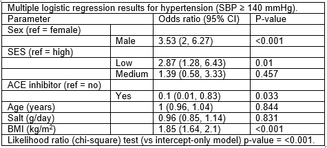

Logistic regression results table

Example statistical and practical interpretation of the relationship between BMI and hypertension status:

The model-predicted that the odds of having hypertension increased by 85% (95% CI: 64%, 110%) for every 1-unit increase in BMI (kg/m²), while holding the effect of all other independent variables constant. Therefore, there was a clear, statistically significant, positive relationship between BMI and hypertension status.

Example statistical and practical interpretation of the relationship between socio-economic status and hypertension status:

The model-predicted that, on average, the odds of having hypertension for individuals in the low socio-economic group were 187% (95% CI: 28%, 543%) higher than the odds of having hypertension for individuals in the high socio-economic group, while, on average, the odds of having hypertension for individuals in the medium socio-economic group were 38% (95% CI: -42%, 233%) higher than the odds of having hypertension for individuals in the high socio-economic group. *Note: as the lower confidence interval was for an odds ratio <1 it represents a percentage reduction in the odds and so you must indicate this by adding a negative symbol. You wouldn’t have to do this if both confidence intervals were reductions if you had verbally stated that the percentage changes were “reduction” or “decreases”, as doing both could be confusing (a double negative).* Therefore, there was a clear, statistically significant, positive relationship between having low socio-economic status compared to high socio-economic status and the odds of having hypertension, but no clear (“statistically non-significant”) relationship between having medium socio-economic status compared to high socio-economic status and the odds of having hypertension.

Example text discussing the key limitations of the study and the issues that must be considered when critically interpreting the results:

Care must be taken when interpreting the results because the study was an observational cross-sectional study with therefore very limited ability to make robust causal inferences, and because the validity and accuracy of the results depends on how well the study data and model have accurately captured the causal relationships of interest and all important confounding variables of those causal relationships, and on how much bias there was in the study.

## 15.11 Next steps (optional)

If you have time you can run a sensitivity analysis for the excessively influential points 478 and 520. Delete the htn values for these observations (which will exclude all their data from the model) and re-run the model. What happens to the results?

Although there are some minor changes, with the largest being for the effect of taking an ACE inhibitor, it seems fair to say there are no substantial changes to the interpretation of the results. You can therefore have greater confidence in the robustness of the primary results.

# 16 Complex survey analysis

## 16.1 Overview

Complex survey analysis as it is commonly known is simply the analysis of complex survey data using appropriately modified methods. You may also see it referred to as complex sample analysis. Despite the common name of complex survey analysis complex survey data does not have to have come from a “survey”, which doesn’t actually define a study design, although most complex survey datasets will be surveys. More generally or technically speaking, complex survey data is any dataset (i.e. sample) that has come from a probability sampling method that has any combination of the following three “complex design features”, with all three often being present together:

1. Stratification
2. Cluster or clustered sampling
3. Unequal probabilities of selection for sampling units

Such data may have come from a single cross-sectional sample, multiple cross-sectional samples (i.e. multiple samples across time of different sampling units), or be true longitudinal data (i.e. multiple samples across time of the same sampling units).

This type of data is most commonly encountered/analysed in global health research when working with large-scale, typically national-scale, cross-sectional household surveys, such as the Demographic and Health Surveys (DHS: https://dhsprogram.com/), the Multiple Indicator Cluster Surveys (MICS: https://mics.unicef.org/), the WHO STEPwise Approach to surveillance Surveys (STEPS: https://www.who.int/ncds/surveillance/steps/en/), and many countries’ own household surveys. This is because large-scale household surveys almost always use all three of these key complex survey features of stratification, cluster sampling, and unequal probabilities of selection of sampling units. The reason they do this is usually for both pragmatic, logistical, and statistical/research reasons. Specifically, stratified sampling is often employed to both allow strata (typically an administrative level such as the region, often further stratified into urban and rural areas) to be independently sampled to ensure that each strata has a sufficient sample size to allow inferences to be made at the strata-level. Cluster sampling is primarily employed to reduce the logistical costs of sampling across huge geographical areas. While stratification and the multi-stage cluster sampling methods employed result in unequal probabilities of selection for sampling units (typically individuals).

Standard methods of analysis, or more technically the maths underlying those methods, such as the independent t-test and linear regression, assume that the data being analysed come from a simple random sample. However, any of the complex survey features mentioned above result in a violation of that assumption, which if not adjusted for would result in either biased point estimates (e.g. biased regression coefficients) and/or biased standard errors of those point estimates (i.e. biased variance estimates), which means biased confidence intervals and p-values. More specifically, not adjusting for clustering typically results in falsely narrow confidence intervals/falsely small p-values, while not adjusting for stratification can mean the analysis “misses out” of the benefits of a stratified sample, which can reduce the overall variation in the outcome and produce more precise results for a given sample size. And not adjusting for unequal probabilities of selection of sampling units typically results in both biased/inaccurate point estimates of characteristics/relationships and falsely narrow confidence intervals/falsely small p-values. Therefore, it is critical that we account or adjust for any complex survey design features in our analyses to obtain unbiased results.

Luckily there are modifications to all commonly used analytical methods, including t-tests and regression models (i.e. linear and logistic and others that we’ve not looked at). And also fortunately we don’t have to worry about the underlying maths. With statistical software like SPSS primarily all we have to do is tell the software which variables code for, or identify, the different complex design features, and then select the appropriate complex survey design version of the analysis we want to do. Then we proceed with our analysis like we would if we were analysing data from a simple random sample, i.e. using the processes outlined in the earlier practical sessions.

In any high quality complex survey dataset that used stratification, cluster sampling, and unequal probabilities of selection of sampling units in its sampling design, there will be a variable that indicates which strata each observation (sampling unit) comes from and a variable that indicates which cluster sampling unit each observation comes from. There will also be a third variable that contains the survey weights, which are used to adjust for the unequal probabilities of selection of sampling units.

To explain weights briefly, because sampling with unequal probabilities of selection of sampling units results in a unrepresentative sample (i.e. unrepresentative of the target population), to “map” the survey sample back onto the target population survey data producers calculate sampling weights. In the analysis these weights upweight (or increase the contribution) of observations from sampling units that were undersampled compared to proportion of the target population that they represent, and they downweight (or decrease the contribution) of observations from sampling units that were oversampled compared to proportion of the target population that they represent. These weights are then usually combined with other weights that further attempt to correct for missing observations and any remaining unrepresentativeness of the sample compared to the target population based on (if available) robust pre-existing data on characteristics of the target population (such as a recent census). This then results in a final or ultimate survey weight variable.

Therefore, once we’ve identified these three variables and “told” SPSS which variables they are we can analyse our data and largely forget/ignore the fact that we are doing a complex survey version of our chosen analysis. The type of results we get and their interpretation will, broadly speaking, not change apart from in a few areas that we will look at in this practical session.

## 16.2 Further reading

Unfortunately, the best and most beginner-friendly textbook on complex survey data analysis, which also included examples using SPSS (as well as other statistical software) is now no longer available from the library (it was previously available online via the library). This book is: Heeringa, S., West, B.T., Berglund, P.A. (2017). Applied Survey Data Analysis (2nd ed.). Boca Raton, FL, USA: CRC Press. If you do plan on conducting complex survey analyses in your later careers I would strongly recommend buying the book, as it’s well worth it. The accompanying website also has lots of practice examples of analyses in SPSS and other statistical software. Unfortunately there are not any similar textbooks that I am aware of for complex survey analysis.

However, there is a nice overview/summary of the main issues around complex survey data analysis in the following paper, by one of the authors of the book I’ve just mentioned, which is freely available here:

https://pubmed.ncbi.nlm.nih.gov/18956450/

## 16.3 Preparing for complex survey data analysis: a checklist

The following is an excellent future reference checklist of steps to undertake when preparing to analyse complex survey data in a real analysis. It is taken from the Applied Survey Data Analysis textbook mentioned previously. For this practical we will assume we have carried out steps 1-3 and step 5 to save time, and some of the issues mentioned are beyond the scope of this introductory course/session, but if you were to do complex survey analysis for a real study or later in your career you should educate yourself enough to understand all these terms and the issues they refer to (e.g. by buying and reading the recommended textbook).

1. Review the documentation for the data set provided by the data producer, specifically focusing on sections discussing the development of the final survey weights and sampling error (standard error) estimation. Contact the data producer if any questions arise.
2. Identify the correct weight variable for the analysis, keeping in mind that many survey data sets include separate weights for different types of analyses. Perform simple descriptive analyses of the weight variable, noting the general distribution of the weights, whether the weights have been normalized, and whether there are missing or 0 weight values for some cases. Select a few key variables from the survey data set and compare weighted and unweighted estimates of descriptive parameters (e.g., means, proportions) for these variables to understand the effect the weights have.
3. Identify the variables in the data set containing the “sampling error calculation codes” that define the sampling error calculation model [JPH: these are just the variables defining the strata and clusters]. Examine how many clusters were selected from each sampling stratum (according to the sampling error calculation model), and whether particular clusters have small sample sizes. If only a single sampling error cluster is identified in a sampling stratum, contact the data producer or consult the documentation for the data set for guidance on recommended variance estimation methods. Determine whether replicate sampling weights are present if sampling error calculation codes are not available, and make sure that the statistical software is capable of accommodating replicate weights (Section 4.2.1).
4. Create a final analysis data set containing only the analysis variables of interest (including the survey weights, sampling error calculation variables, and case identifiers) [JPH: this is optional. It’s nice to keep your dataset tidy and no bigger than necessary for speed and manageability, but it obviously doesn’t affect the analysis in anyway]. Examine univariate and bivariate summaries for the key analysis variables to determine possible problems with missing data or unusual values on the individual variables.
5. Review the documentation provided by the data producer to understand the procedure (typically nonresponse adjustment) used to address unit nonresponse or nonresponse to a wave or phase of the survey data collection. Analyse the rates and patterns of item missing data for all variables that will be included in the analysis. Investigate the potential missing data mechanism by defining indicator variables flagging missing data for the analysis variables of interest. Use statistical tests (e.g., chi-square tests, two-sample t-tests) to see if there are any systematic differences between respondents providing complete responses and respondents failing to provide complete responses on important analysis variables (e.g., demographics). Choose an appropriate strategy for addressing missing data using the guidance provided in Section 4.4 and Chapter 12 [JPH: we will not look at missing data issues in this practical, but most high quality complex survey datasets, such as the DHS surveys, include weights that incorporate adjustments for missing data that, while not perfect by any means, go some way to addressing bias from missing data by simply including the weights in the analysis as you should be doing anyway].
6. Define indicator variables for important analysis subclasses. Do not delete cases that are not a part of the primary analysis subclass. Assess a cross-tabulation of the stratum and cluster sampling error calculation codes for the subclass cases to identify the distribution of the subclass across the strata and clusters defined by the sampling error calculation model. Consult a survey statistician prior to analysis of subclasses that exhibit the “mixed class” characteristic illustrated in Figure 4.4. Make sure to employ appropriate software options for unconditional subclass analyses if using TSL for variance estimation [JPH: we will look at this issue in more detail later in this practical session].

## 16.4 Scenario

The dataset we will use here is one of the DHS’s “model datasets”, and as such it was produced by the DHS for practicing analysis of DHS survey data. It is therefore representative of the types of data and data features (e.g. complex survey features) found in DHS surveys, but it doesn’t contain any real data from any country. DHS surveys typically result in the production of a number of datasets, primarily a household-level dataset and datasets for women, men, and children, plus potentially others. You can read more about DHS datasets here: https://dhsprogram.com/data/

However, we will just use the “individual recode” dataset in the SPSS .sav format (DHS helpfully makes their datasets available in other formats too). This contains data from the female respondents of the survey, who consist of all members of a selected household who are aged 15-49. This dataset is included in the “Datasets” folder of the “YCHI5045M computer practical.zip”, and is called “ZZIR62FL.SAV”. The “odd” naming is due to DHS’s naming conventions, which you can read about here: https://www.dhsprogram.com/data/File-Types-and-Names.cfm

More specifically, we will use the dataset to answer the research question “what factors affect the time women report it takes someone from their household to reach the household’s source of drinking water?”

We will assume that our causal inference based model building process has led us to hypothesise that the most likely set of causal influences on the time household members take to reach the household’s source of drinking water are:

- The household location (urban or rural)
- The wealth level of the household
- The age of the “head of the household”

Of course this is just a simplified assumption to make things easier for learning purposes. Then like with our regression analyses, and unlike in a proper causal inference driven approach, we will make the simplifying assumption that we are interested in the relationship between each of these independent variables and the outcome variable of “time household members take to reach the household’s source of drinking water”, i.e. we assume all these independent variables are likely causally related to the outcome, but that together these independent variables collectively form the sufficient adjustment set for each of the separate focal relationships. Therefore, like with our regression analyses to simplify things we will just create one model containing all these variables and interpret the results as though we had, to the best of our knowledge, adjusted for all likely sources of confounding for each focal relationship.

First of all though we will identify, explore, and edit as necessary the key complex design variables of the survey. We will then explore our independent and outcome variables, and then produce descriptive statistics to describe the sample’s characteristics in terms of the variables measured, as would commonly be found in the “Table 1” of a paper. Then finally we will produce our analytical model results.

## 16.5 Step 1: prepare and explore the data

Video: prepare and explore the data

As per the checklist steps 1-3 for any complex survey analysis you must first thoroughly review the survey technical/methodological documentation to understand the design of the survey and sampling process, and to understand which variables contain the stratification, clustering, and weighting information, and to understand any modifications of those variables that are required. To save time we will assume we have done this, and that we have removed all variables from the dataset other than these design variables and the independent and outcome variables.

Therefore, open the ZZIR62FL.SAV dataset. If a window appears with a message starting “IBM SPSS Statistics is running in Unicode encoding mode…” just click Yes. We can assume that from reading the relevant technical/methodological literature on this survey we have identified the relevant complex design variables and our variables of interest and removed all other variables from the dataset. The information on the complex design variables can be found in the “DHS Guide to Statistics” (https://dhsprogram.com/data/Guide-to-DHS-Statistics/Analyzing_DHS_Data.htm), but you should also review the survey specific literature (each DHS survey has a final report with specific methodological details relevant to that survey, along with a full copy of the questionnaire used that you should always review).

We see that we have seven variables:

- V005 = Women’s individual sample weight (6 decimals)
- V021 = Primary sampling unit
- V023 = Stratification used in sample design
- V025 = Type of place of residence
- V115 = Time to get to water source
- V152 = Age of household head
- V190 = Wealth index

**Explore and edit the complex design variables**

Therefore, V005 identifies the survey weights, V021 identifies the clusters (often called primary sampling units as they are the first stage of a multi-stage cluster sample), and V023 identifies the strata. However, and this shows why you must read survey methodological literature carefully, all DHS weights are stored multiplied by 1,000,000. This is for very technical computer science related reasons about floating point errors that we don’t need to go into here, but the point is that to use the weight variable we therefore need to first divide all values by 1,000,000.

To do this from the main menu go: Transform > Compute Variable. Then in the Target Variable: box give our new variable a suitable name, say “survey_weight”, and in the Numeric Expression: box enter the following:

> V005 / 1000000

Then click OK. You can now delete the old V005 variable if you wish.

Before we go any further let’s rename the other variables for ease of reference. We’ll use the following names:

- V021 = cluster
- V023 = strata
- V025 = location
- V115 = time_water
- V152 = age_hhh
- V190 = wealth

And let’s also change the variables cluster, strata, location, and wealth to the variable type nominal so SPSS treats them as categorical variables (as they use numerical coding SPSS automatically treats them as numerical variables unless told otherwise).

**Explore and edit the data variables**

Next let’s explore each of the data variables in turn. Again for a quick univariate exploration we can just use the same process as we used to explore the complex design variables. What do the descriptive statistics and histogram show you for the four data variables?

There are no missing values for location, and there is a ~40%:60% split between urban and rural located households of the women surveyed. There are 13 missing values of our outcome variable time_water, and a histogram indicates that the variable appears to have a strongly “bimodal” distribution with two distinct “peaks”, but we’ll come back this shortly. There are 6 missing values of age_hhh, and a histogram indicates that the variable is fairly normally distributed. There are no missing values of wealth, and observations are evenly distributed across it’s five levels. This is to be expected because in DHS surveys the numerical household wealth index is categorised into five wealth quintiles by evenly separating increasing values of the variable into five levels/groups.

So back to the outcome variable. This is a good example of why a careful data exploration is important prior to any analysis, and why understanding your survey data and methodological documentation is so important. You can access the questionnaire that the model dataset is based on here: https://dhsprogram.com/pubs/pdf/DHSQ6/DHS6_Questionnaires_5Nov2012_DHSQ6.pdf

Scroll down to question 104 “How long does it take to go there, get water, and come back?”, which is where our variable comes from. What can you see about the possible response values?

Respondents can provide the number of minutes it takes them to go and collect water and come back, but for those who don’t know their response is coded as 998:, which is the second peak we see on the histogram. Therefore, the distribution is not bimodal at all, we’re just not looking at only the true/non-missing values.

Therefore, let’s just look at the distribution of non-missing values for our outcome. Instead of deleting all observations where the response was “don’t know” to our question of interest we can tell SPSS to treat the value 998 as a missing value for this variable. In the Variable View for the time_water row click on the cell under the column Missing and click on the box with three dots in that appears to the right of the cell. In the Missing Values box that appears click the Discrete missing values button and in the first box enter 998 and then click OK. Now re-run the histogram and what do you see?

The distribution of values is clearly strongly right-skewed. Remember that linear regression assumes that the *residuals* are approximately normally distributed not the raw values of the outcome, and therefore once we adjust for all our independent variables our model may be valid. However, with such strong right-skew it looks likely that we’ll have to transform the outcome or use a different model (e.g. a valid alternative would be to dichotomise the outcome, i.e. convert it into a binary variable, and use a logistic regression, although that would throw away a lot of statistical information and result in cruder inferences). We shall see!

**Explore bivariate relationships**

Let’s look at the relationships between our independent variables and our outcome to check for any clearly non-linear relationships. In a real analysis we would also want to check for the presence of strong interactions, ideally that we would expect from theory, but that is beyond the scope of this practical and course.

As previously for numerical independent variables we use scatter plots.

- From the menu go: Graphs > Legacy Dialogues > Scatter/Dot, then select the default top-left Simple scatter option and click Define. Then add age_hhh and water_time to the appropriate X Axis: and Y Axis: boxes respectively and click OK.

It’s hard to see much of a relationship there, and certainly no clear non-linear relationship.

Then for the two categorical independent variables again we can use box plots.

- From the main menu go: Graphs > Legacy Dialogues > Boxplot, then select Simple and click Define. Add the water_time variable into the Variable: box and location into the Category Axis: box and click OK.

It’s also hard to see much of a clear relationship here, but the median time for urban looks slightly higher than the median time for rural, but clearly there’s a lot of variation in both category levels. If you repeat the graph but for wealth what do you see? Again, personally I can’t see any clear relationships here.

## 16.6 Step 2: create the “SPSS complex samples plan file”

Video: create the “SPSS complex samples plan file”

As mentioned previously in order to undertake valid analysis of a complex design dataset we must first tell SPSS which variables code for the complex design features in our sample. We only need to do this once.

- To do this from the main menu go: Analyse > Complex Samples > Prepare for Analysis. Then with the Create a plan file button selected click Next. Then in the Save Data As window that opens we need to first create a complex samples plan file that SPSS can store the information in about which variables code for the complex design features. Therefore, navigate to a suitable folder and enter a suitable name for the plan into the File name: box, such as “water_survey”, and then click Save. You can now identify the complex design variables coding for the strata, clusters, and weights to SPSS. Note: if you are working with data that comes from a complex sample using few than all three of these design features you can of course just identify those.
- In the Analysis Preparation Wizard simply add the strata variable into the Strata: box, the cluster variable into the Clusters: box, and the survey_weight variable into the Sample Weight: box. You can then just click Finish, because the default options are that you can set on the next pages by clicking Next are suitable.

You have now created your sampling plan file which can be reused for any analysis of this dataset, and we can now run any analysis that can account for a complex design using this file and SPSS will adjust for the stratification, clustering and weights.

## 16.7 Step 3: describe the sample

Video: describe the sample

Note: if you feel you are short on time then skip this exercise and move onto the next exercise that focuses on producing the inferential results.

We will calculate the mean for water_time and age_hhh and the frequency and percentage for each category level of location and wealth. Let’s start with the numerical independent variables.

- From the main menu go: Analyse > Complex Samples > Descriptives, then in the Complex Samples Plan for Descriptives Analysis tool just click Continue as the complex samples plan file will be automatically selected. If for any reason it is not click Browse and locate and select it before clicking Continue.
- Now in the Complex Samples Descriptives tool add time_water and age_hhh to the Measures: box. Then click the Statistics button and ensure that the Mean button is ticked and click Continue. For some reason there is no option to calculate the standard deviation or median. The range isn’t affected by the complex design features though so you could still calculate that using the standard tool.

You’ll see that water_time has a mean of 24.61 and age_hhh has a mean of 45.48. These are both adjusted for the complex design features of the sample. To compare to an analysis ignoring these features right click on the water_time variable and select the Descriptive Statistics option. You’ll see that the mean for water_time is 23.74 when you ignore the complex design features. In this instance it’s not a big difference, but this is the affect of accounting for the weights variable.

Now let’s calculate the frequency and percentage for each category level of location and wealth.

- From the main menu go: Analyse > Complex Samples > Frequencies, then in the Complex Samples Plan for Descriptives Analysis tool just click Continue as the complex samples plan file will be automatically selected. If for any reason it is not click Browse and locate and select it before clicking Continue.
- Now in the Complex Samples for Frequencies Analysis tool add location and wealth to the Frequency Tables: box, then click the Statistics button and select the Population size, Table percent, and the Unweighted count tick boxes, and then click Continue and then OK.

The resulting tables are not helpfully laid out! The **Estimate** column gives the frequencies adjusted for the weights in the top half of the table and the corresponding percentages adjusted for the weights in the bottom half of the table. Then the **Unweighted count** gives the frequencies not adjusted for the weights in both the top and bottom halves of the table, i.e. the values are just repeated for some unclear reason.

For both means and frequencies and percentages you would usually want to provide the weight-adjusted descriptive statistics because they reflect the target population that you are making inferences to, given that the unadjusted sample results will be, by the sampling design, not representative of that target population while the adjusted results aim to be.

## 16.8 Step 4: create the complex design linear regression model

We are now ready to produce our analytical inferential statistics via our linear regression model. Again we can just use our existing complex samples plan file to adjust for the complex design features using the appropriate complex design linear regression tool.

- From the main menu go: Analyse > Complex Samples > General Linear Model. Remember a general linear model is a synonym for a linear regression.
- On the Complex Samples Plan for General Linear Model tool click Continue. Now add water_time into the Dependent Variable: box, location and wealth into the Factors: box, and age_hhh into the Covariates: box. By default just the main effects of each variable are included in the model so unless you want to specify interactions you can ignore the Model button.
- Next click the Statistics button and in the Model Parameters area ensure the Estimate and Confidence interval boxes are ticked, along with the Model Fit and Sample design information boxes below. Then click Continue.
- We can ignore the Hypothesis Tests button and the Estimated Means button, but click the Save button and in the Save Variables are ensure the Predicted Values and Residuals boxes are ticked then click Continue.
- We can also ignore the Options box so just click OK.

## 16.9 Step 5: check the assumptions of the complex design linear regression model

Video: check the assumptions of the complex design linear regression model

However, as always before interpreting the results we should check the model’s assumption are not violated. In particular, we should check that the residuals are approximately normally distributed and not heteroscedastic. To check the first of these just plot a histogram of the saved residual values (the variable should be called Residual). What do you see?

The residuals are clearly strongly right-skewed!

Therefore, we can either try and transform the outcome or use an alternative analysis, such as a logistic regression after dichotomising the outcome. For now let’s see how we would interpret the results assuming that the assumptions were not violated, and then we will leave it as an exercise for you to re-run the model with a transformed outcome to see if that solves things, and then interpret the back-transformed results.

Note: in a real analysis you should check all assumptions are not violated. Just follow the instructions in the “Step 2: check the assumptions of the linear regression” section in the linear regression practical for guidance, and use the Residuals and Predicted variables produced by the complex design adjusted linear regression we just ran accordingly.

## 16.10 Step 6: understand the results tables

Video: understand the results tables

After running the model we see four tables (scroll up from the residual histogram you should have just created and anything else you’ve done since running the model).

The **Sample Design Information** table tells us some important things about our sample and design. In particular, it tells us how many cases (in our case women) were missing or not missing from the analysis, i.e. our effective sample size: these are the valid and invalid **N** values, as well as the total unweighted sample size (**Total N**). It also tells us the estimated size of the target population, but this is only valid if the weights are not “normalised” to have a mean of 1, which DHS weights areso you can ignore this. It also tells us the number of strata (**Strata**) and clusters (**Units**), which serves as a check if all strata and clusters were included in the analysis or if any were left out due to missing observations in those strata/clusters.

The **Model Summary** table tells us the R² value for the model, although frustratingly not the more robust and useful *adjusted* R² value!

We can ignore the **Test of Model Effects** table as this is an ANOVA type table and not really useful.

Then we have our familar **Parameter Estimates** table where we get our key inferential results about the relationships between the independent variables and the outcome in the model. These are interpreted in exactly the same way as the linear regression coefficients from a linear regression that does not adjust for any complex design features. Therefore, refer back to the “Step 6: report and interpret the results” section of the linear regression practical, and in particular the sub-sections “Numerical variables” and “Categorical variables”, for a reminder if needed.

## 16.11 Exercise: complex design adjusted linear regression

- In the YCHI5045M computer sessions materials “Exercises” folder open the “Exercises.docx” Word document and scroll down to **Complex design adjusted linear regression: the causes of variation in time taken to fetch water**. Then follow the instructions in the exercise.

Example statistical interpretation of the relationship between household location, household wealth, and age of household head, and the time taken for household members to fetch water:

There was a clear, statistically significant relationship between household location and time taken for household members to fetch water, with women from households in location=1 reporting that it took household members a mean of 7.9 minutes (95% CI: 1.5, 14) longer to fetch water than women from households in location=2. However, there was no clear relationship between household wealth or age of household head on the time taken by household members to fetch water. The R² value associated with the model was just 0.03, and therefore the model explained just 3% of the variation in the time taken by household members to fetch water. Therefore, the model explained very little about what is likely to drive differences in the time taken by household members to fetch water. As always the accuracy of these inferences depend on the amount of bias in the study and analysis.

Example statistical interpretation of the relationship between household location, household wealth, and age of household head, and the ln-transformed time taken for household members to fetch water:

Once the outcome was log-transformed the model residuals appeared very normally distributed, but there were no longer any clear relationships between any of the independent variables and the log-transformed outcome.

**Well done for getting to the end! If all of this seemed like very hard work that’s because it is and should be. Anyone can run a logistic regression model using modern statistical software, but hopefully you have a clear understanding that to make robust, valid, and meaningful statistical inferences requires a lot of hard work, careful thought, and (unfortunately) experience that can only come with continuous learning and practice! However, you can hopefully also see that the benefits are huge. Being able to conduct robust and useful statistical analyses is a hugely powerful skill to have. Lastly, hopefully you can also see that it can be interesting and even exciting, but maybe that’s too much to ask at this stage!**

END

To do:

Tidy: add buttons/video links as req Explore data before simple analyses? (already got a data exploration stage in linear regression - check logistic) target pop > sampling population (Check and replace wider pop too) missing data and unusual values in data exploration (uni and multivariate missingness?)